# STAT 501

Statistical Literature and Problems

30 October, 2020

## (Albert & Chib, 1993)

James H. Albert & Siddhartha Chib (1993) Bayesian Analysis of Binary and Polychotomous Response Data, Journal of the American Statistical Association, 88:422, 669-679, [DOI: 10.1080/01621459.1993.10476321](https://doi.org/10.1080/01621459.1993.10476321)

### 1 Introduction

$Y_1,..,Y_n\sim Bern(p_i)$. $\beta_{k\times1}$ unknown vector of parameters. $X_i^T=(X_{i1},..,X_{ik})$ known covariates.

$p_i=H(\mathbf{x}_i^T\boldsymbol{\beta})$. $H(\cdot)$ is a known CDF with linear structure $\mathbf{x}_i^T\boldsymbol{\beta}$

If $H(\cdot)$ is standard normal CDF, it obtains the probit model,

if $H(\cdot)$ is logistic CDF, it obtains the logit model.

$\pi(\boldsymbol{\beta})$ is the prior density.

$\pi(\boldsymbol{\beta}|data) = \frac{\pi(\boldsymbol{\beta})\prod_{i=1}^{k}H (\mathbf{x}_i^T\boldsymbol{\beta})^{y_i}(1-H(\mathbf{x}_i^T\boldsymbol{\beta}))^{1-y_i}}{\int\pi(\boldsymbol{\beta})\prod_{i=1}^{k}H (\mathbf{x}_i^T\boldsymbol{\beta})^{y_i}(1-H(\mathbf{x}_i^T\boldsymbol{\beta}))^{1-y_i}d\boldsymbol{\beta}}$ is intractable.

For small number of parameter, a Bayesian approach summarized the posterior using numerical integration.

For large models (k large), posterior moments by Monte Carlo integration with a `multivariate Student's t importance function`.

This is a simulation-based approach for computing the exact posterior distribution of $\beta$.

The key idea is to introduce $N$ independent latent variables $Z_1,..Z_N\sim N(\mathbf{x}_i^T\boldsymbol{\beta},1)$ into the problem. $Y_i=\begin{cases}1&\text{if } Z_i>0\\0&\text{if }Z_i\le0\end{cases}$

This approach is very simular to the data augmentation/Gibbs sampling framework used in censored regression models.

### 2. The Gibbs Sampler

$\theta_1^{(1)}\quad\text{from}\quad\pi(\theta_1|\{\theta_j^{(0)},j\neq1\})\\ \theta_2^{(1)}\quad\text{from}\quad\pi(\theta_2|\{\theta_1^{(1)},j>2\})\\ \vdots\\ \theta_p^{(1)}\quad\text{from}\quad\pi(\theta_p|\{\theta_j^{(1)},j<p\})\\$

One cycle is iterated $t$ times. For sufficiently large $t^*$, $\theta^{(t^*)}$ can be regarded as one simulated value from the posterior of $\theta$. Replicating this process $m$ times $\{\theta_{1j}^{(t^*)},\theta_{2j}^{(t^*)},..,\theta_{pj}^{(t^*)},j=1,..,m\}$

Two practical drawbacks to the replication approach:

1. The method is inefficient. the samples $\{\theta_j^{(t)}\}$, for $t<t^*$ are discarded.
2. After the initial run it may be necessary to repeat the simulation with a larger number of replication to get accurate density estimates.
- A “one-run” Gibbs sampling scheme is efficient in that few observations are discarded.
1. One should collect the values staring at the cycle $t$. The value of $t$ is samll (10-40) relative to the total number of values collected. (burn-in???)
2. If one wishes to obtain an approximate independent sample of the $\theta$, the simulated values of $\theta$ could be collected at cycles $t,t+n_1,t+2n_1,..$, where $n_1$ is the spacing between cycles where $\theta^{(t)}$ and $\theta^{(t)}$ are believed to be approximately independent. *But it is not necessary to obtain an independent sample of $\theta$ to obtain, say, a marginal posterior density estimate of $\theta_k$* ???
- One goal of this article is to obtain estimates of the densities of the individual parameters or their functional.

One can estimate the density of this function using a *kernel density* estimate of the simulated values of $g(\theta_k)\{\theta_k^{(i)},i=1,..,m\}$. A slightly preferable estimate of this marginal posterior density is given by $\hat\pi(g(\theta_k))\approx\frac1m\sum_{i=1}^m\pi(g(\theta_k)\{\theta_r^{(i)},r\neq k\})$ ???

In practice, we collect values of $\theta$ in batches of 100-200 until all the marginal density estimates for the components of $\theta$ stabilize.

- A second goal is estimation of posterior expectations.

To compute this standard error from this correlated simulation sample, we apply *the well-known batch means method*. We batch or section the sample into subsamples of equal size. When the lag one autocorrelation of the batch means is under .05, the simulation standard error is computed as the standard deviation of the batch means divided by the square root of the number of batches. $se=\frac{sd}{\sqrt{B}}$ subsamples of equal size???

### 3 Data augmentation and Gibbs sampling

#### 3.1 Introduction

$$\begin{align}
\pi(\boldsymbol{\beta|y,Z}) = C\pi(\boldsymbol{\beta})\prod_{i=1}^{N}\phi (Z_{i};\mathbf{x}_i^T\boldsymbol{\beta},1); &\quad\mathbf{Z}=\mathbf{X}\boldsymbol{\beta+\varepsilon}; &\quad \boldsymbol{\varepsilon}\sim N_N(0,\mathbf{I})&&(1)\\
\\
\boldsymbol{\beta}|\mathbf{y,Z}\sim N_k(\boldsymbol{\hat\beta_Z},(\mathbf{X}^T\mathbf{X})^{-1}); &\quad\boldsymbol{\hat\beta_Z}=(\mathbf{X}^T\mathbf{X})^{-1}\mathbf{X}^T\mathbf{Z}&&& (2)\\
\\
Z_i|\boldsymbol{y,\beta}\sim N(\mathbf{x}_i^T\boldsymbol{\beta},1) &\quad\text{truncated at the left by 0} & \text{if } y_i=1 &&\\
&\quad\text{truncated at the right by 0} & \text{if } y_i=0 &&(3)
\end{align}$$

The starting value $\beta^{(0)}$ may be taken to be the maximum likelihood (ML) estimate, or least squares (LS) estimate $(\mathbf{X}^T\mathbf{X})^{-1}\mathbf{X}^T\mathbf{y}$

#### 3.2 The $t$ Link

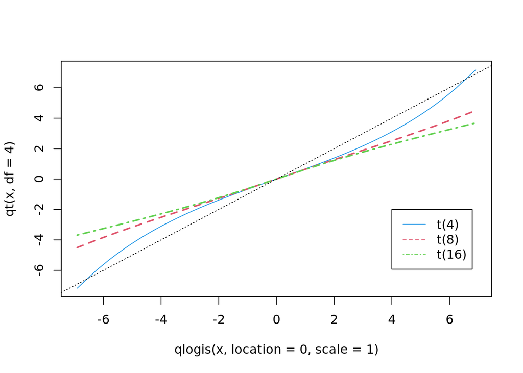

```r
x <- seq(0.001,.999,0.001)
plot(qlogis(x,location=0,scale=1),qt(x,df=4),col=4,type = "l")
lines(qlogis(x,location=0,scale=1),qt(x,df=8), col = 2, lty = 2, lwd = 2, add = TRUE)
lines(qlogis(x,location=0,scale=1),qt(x,df=16), col = 3, lty = 4, lwd = 2, add = TRUE)
abline(a=0,b=1, lty = 3, add = TRUE)
legend(4,-2,c("t(4)","t(8)","t(16)"),col = c(4,2,3),lty = c(1,2,4))
```

$\mathbf{Y}\sim Bern(p_i)$ have an underlying $N(Z)$; $\boldsymbol{\beta}|\mathbf{Z}\sim N_k()$; generalize mixtures of Normal distribution.

$H()=t$ *investigate the sensitivity* of the fitted probabilities to the choice of link function.

The most popular link function for binary data is the logit, which corresponds to a choice of a logistic distribution for $H$

Logistic quantiles are approximately a linear function of $t(8)$ quantiles. The logistic distribution has the same kurtosis as a $t$ distribution with 9 df.

$Z_i\sim t_{\nu}(\mathbf{x}_i^T\boldsymbol{\beta},1)$ equivalently, $Z_i|\lambda_i\sim N(\mathbf{x}_i^T\boldsymbol{\beta},\lambda_i^{-1})$; $\lambda_i\sim Gamma(\frac{\nu}{2},\frac{2}{\nu})\propto\lambda_i^{\frac{\nu}{2}-1}\exp(-\frac{\nu\lambda_i}{2})$; Suppose $\beta\sim Unif()$

$$\begin{align}
\boldsymbol{\beta|y,Z,\lambda,\nu}\sim N_k(\boldsymbol{\hat\beta_{Z,\lambda}},(\mathbf{X'WX})^{-1}); &\quad\boldsymbol{\hat\beta_{Z,\lambda}}=(\mathbf{X'WX})^{-1}\mathbf{X'WZ},\ \mathbf{W}=\mathrm{diag}(\lambda_i) &&& (4)\\
\\
\boldsymbol{Z_i|y,\beta,\lambda,\nu}\sim N(\mathbf{x}_i^T\boldsymbol{\beta},\lambda_i^{-1}) &\quad\text{truncated at the left by 0} & \text{if } y_i=1 &&\\
&\quad\text{truncated at the right by 0} & \text{if } y_i=0 &&(5)\\
\\
\boldsymbol{\lambda_{1:N}|y,Z,\beta,\nu}\sim Gamma(\frac{\nu+1}{2},\frac{2}{\nu+(Z_i-\mathbf{x}_i^T\boldsymbol{\beta})^2})&\quad\text{independent with } \lambda_i&&&(6)\\
\boldsymbol{\nu|y,Z,\beta,\lambda}\propto\pi(\nu)\prod_{i=1}^N(c(\nu)\lambda_i^{\frac{\nu}{2}-1}e^{-\frac{\nu\lambda_i}{2}})&\quad\text{in a finite set}&&&(7)\\
\end{align}$$

$\beta^{(0)}=$ least squares (LS) estimate under the probit model, set $\lambda_i=1,\forall i$

$$\hat\pi(\boldsymbol{\beta})\approx\frac1m\sum_{i=1}^m\pi(\boldsymbol{\beta|Z^{(i)},\lambda^{(i)}})$$

$p_k=\Phi(\lambda_k^{\frac12}\mathbf{x}_k^T\boldsymbol{\beta})$ by a transformation of the conditional density of $\beta$

$$\hat\pi(p_k)=\frac1m\sum_{i=1}^m\frac{\phi(\Phi(p_k);\mu,\sigma^2)}{\phi(\Phi(p_k);0,1)}$$

$\mu=\sqrt{\lambda_k^{(i)}}\mathbf{x}_k^T\boldsymbol{\hat\beta_{Z,\lambda}^{mu3(i)}}$ ????

$\sigma^2=\lambda_k^{(i)}\mathbf{x}_k^T(\mathbf{X'WX})^{-1}\mathbf{x}_k$

#### 3.3 Hierarchical Analysis

1. $\mathbf{Z}\sim N(\boldsymbol{X\beta,I})$, (2) $\boldsymbol{\beta}\sim N(\boldsymbol{A\beta^{(0)},\sigma^2I})$, (3) prior density $\pi(\boldsymbol{\beta^{(0)},\sigma^2})\qquad$ (8)

The hyperparameters $\boldsymbol{\beta^{(0)}}\sim Unif()$, $\sigma^2$ given a noninformative prior ????

The posterior density of the regression vector $\beta$ compromises between least squares estimates from the “full” k-dimensional model and the “reduced” p-dimensional model where $\boldsymbol{\beta=A\beta^{(0)}}$

$$\begin{align}
\boldsymbol{\beta|Z,\sigma^2}&\sim N_k(\boldsymbol{\mu,V}) &&(9)\\
\boldsymbol{\mu}&=\boldsymbol{W_1\hat\theta_1+(I-W_1)A\hat\theta_2} \\
\boldsymbol{\hat\theta_1}&=(\mathbf{X'X})^{-1}\mathbf{X'Z} \\
\boldsymbol{\hat\theta_1}&=(\mathbf{X'X})^{-1}\mathbf{X'Z} \\
\boldsymbol{V}&=\boldsymbol{((I-W_1)A)[A^TX^T(I+XX^T\sigma^2)^{-1}XA]^{-1}((I-W_1)A)^T+[X^TX+I/\sigma^2]^{-1}} \\
\boldsymbol{\sigma^2|Z}&\propto c(\mathbf{Z)\frac{|(I+XX^T\sigma^2)^{-1}|^{\frac12}}{|A^TX^T(I+XX^T\sigma^2)^{-1}XA|^{\frac12}}}\exp{\left\{\frac12Q(\boldsymbol{Z,XA\hat\theta_2,I+XX^T\sigma^2})\right\}}\pi(\sigma^2) &&(10)\\
\end{align}$$

where $Q(\boldsymbol{Z,\mu,\Sigma})=\boldsymbol{(Z-\mu)^T\Sigma^{-1}(Z-\mu)}$ and $c(\mathbf{Z)}$ is a proportionality constant.

one starts with initial guesses at $\boldsymbol{\beta}$ and $\sigma^2$, simulates the $Z_i$ from (3), and then simulates $\boldsymbol{\beta}$ and $\sigma^2$ from the distributions (9) and (10)

### 4 Generalizations to a Multinomial response

#### 4.1 Ordered Categories

$Y_1,..,Y_N$ are observed. $Y_i$ takes one of $J$ ordered categories. $p_{ij}=P[Y_i=j]$, we define the cumulative probabilities $\eta_{ij}=\sum_{k=1}^jp_{ij},j=1,..,J-1$ k????

One popular regression model is given by $\eta_{ij}=\Phi(\gamma_i-\mathbf{x}_i^T\boldsymbol{\beta}),i=1,..,N; j=1,..,J-1$

A latent continuous variable $Z_i\sim N(\mathbf{x}_i^T\boldsymbol{\beta},1)$. $Y_i=j\text{ if } \gamma_{j-1}<Z_i\le\gamma_{j}, \gamma_{0}=-\infty,\gamma_{J}=\infty$

The posterior distribution of $\beta$ conditional on $y$ and $Z$ is given by the multivariate normal form (2)

$$\begin{align}
\pi(\boldsymbol{\beta,\gamma|y})&= C\pi(\boldsymbol{\beta})\prod_{i=1}^{N}\sum_{j=1}^{J}\mathbf{1}_{(y_i=j)}[\Phi (\gamma_{j}-\mathbf{x}_i^T\boldsymbol{\beta})-\Phi (\gamma_{j-1}-\mathbf{x}_i^T\boldsymbol{\beta})]\\
\pi(\boldsymbol{\beta,\gamma,Z|y})&= C\prod_{i=1}^{N}\left[\frac{1}{\sqrt{2\pi}}\exp(-\frac12(Z_i-\mathbf{x}_i^T\boldsymbol{\beta})^2)(\sum_{j=1}^{J}\mathbf{1}_{(Y_i=j)}\mathbf{1}_{(\gamma_{j-1}<Z_i\le\gamma_{j})})\right]&&(11)\\
Z_i|\boldsymbol{\beta,\gamma},y_i&\sim N(\mathbf{x}_i^T\boldsymbol{\beta},1) \quad\text{truncated at the left(right) by } \gamma_{j-1}(\gamma_{j}) &&(12)\\
\gamma_j|\boldsymbol{Z,y,\beta,},\{\gamma_k,k\neq j\}&\propto \prod_{i=1}^{N}\left[\mathbf{1}_{(Y_i=j)}\mathbf{1}_{(\gamma_{j-1}<Z_i\le\gamma_{j})})+\mathbf{1}_{(Y_i=j+1)}\mathbf{1}_{(\gamma_{j}<Z_i\le\gamma_{j+1})})\right]&&(13)\\
\end{align}$$

13. can be seen to be uniform on the interval $[\max \{\max \{Z_i: Y_i = j \}, \gamma_{j-1} \}, \min \{\min \{Z_i: Y_i = j + 1\}, \gamma_{j+1} \}]$.

To implement the Gibbs sampler here, start with ($\beta,\gamma$) set equal to the MLE and simulate from the distributions (13), (12), and (1), in that order.

#### 4.2 Unordered Categories With a Latent Multinormal Distribution

We introduce independent latent variables $Z_i=(Z_{i1},..,Z_{iJ})(J>2)$ and define $Z_{ij}=\mathbf{x}_{ij}^T\boldsymbol{\beta}+\varepsilon_{ij},\ i=1,..,N;j=1,..,J$, whrre $\varepsilon_i=(\varepsilon_{i1},..,\varepsilon_{iJ})^T\sim N_J(\mathbf{0,\Sigma_{J\times J}})$

$\mathbf{\Sigma}$ is parameterized in terms of a parameter vector $\theta$ of dimension not exceeding $\frac12J(J-1)$.

On unit $i$ we observe one of $J$ possible outcomes with respective probabilities $p_{i1},..,p_{ij}$. Category $j$ is observed if $Z_{ij}>Z_{ik}$ for all $k\neq j$.

The multinomial logit model can be derived in this setup if and only if the errors $\varepsilon_{ij}$ are a random sample from a Type I extreme value distribution. The multinomial probabilities are given by $p_{ij}=P[\mathbf{x}_{ij}^T\boldsymbol{\beta}+\varepsilon_{ij}>\mathbf{x}_{ik}^T\boldsymbol{\beta}+\varepsilon_{ik}, \forall k\neq j]$

$\mathbf{Z=X}\boldsymbol{\beta+\varepsilon}$ where $\varepsilon=(\varepsilon_{1}^T,..,\varepsilon_{N}^T)^T\sim N_{NJ}(\mathbf{0,I_N\otimes\Sigma})$

$$\begin{align}
\boldsymbol{\beta|Z_{1:N},Y,\theta}&\sim N_k(\boldsymbol{\hat\beta_{Z}},(\mathbf{X'\Omega^{-1} X})^{-1}); \quad\boldsymbol{\hat\beta_{Z}}=(\mathbf{X'\Omega^{-1} X})^{-1}\mathbf{X'\Omega^{-1} Z}\\
\boldsymbol{Z_i|y,\beta,\theta,\{Z_i\}}&\sim N(\mathbf{x}_i^T\boldsymbol{\beta},\Sigma) \quad\text{such that
the }y_i^{th}\text{ component of }Z_i\text{ is the maximum} &&\\
\boldsymbol{\theta|Z_{1:N},Y,\beta}&\propto \boldsymbol{\pi(\theta)|\Omega|^{-\frac12}} \exp\left[-\frac12\boldsymbol{(Z-X\beta)^T\Omega^{-1}(Z-X\beta)}\right]&&(14)\\
\end{align}$$

$\mathbf{\Omega}^{-1}$ is a block diagonal matrix with $\mathbf{\Sigma}^{-1}$ as the typical block. ???

### 5.1 Finney Data

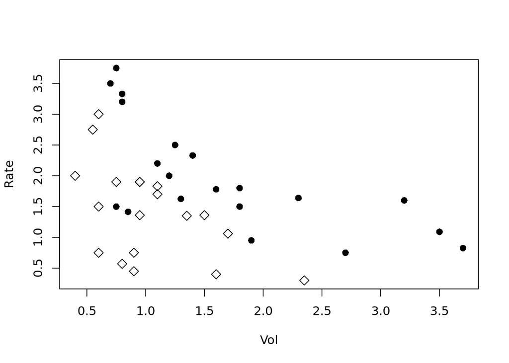

```r
data(Finney)
Vol <- Finney$Vol; Rate <- Finney$Rate; Resp <- Finney$Resp
lVol <-log(Vol); lRate <- log(Rate)
# plotFdat <- Finney$plotFdat
# plotFdat(Rs=Resp,lV=lVol,lR=lRate,zc,zr,rob=F,cont=F)
plot(Vol,Rate,type="n",xlab="Vol",ylab="Rate")
points(Vol[Resp==0],Rate[Resp==0],pch=5, cex=1.2)
points(Vol[Resp==1],Rate[Resp==1],pch=16,cex=1.2)
```

```r
finney <- data.frame(Finney[1:3])
finney[,3] <- as.factor(finney[,3])
table(finney[3])
```

```
##
##  0  1
## 19 20
```

```r
n <- nrow(finney)
```

### Compare with the results after log transform

What is the benifit of log transform?

```r
fit.probit.lm.l <- lm(Resp~lVol+lRate)
fit.probit.glm.l <- glm(Resp~lVol+lRate,family=binomial(link="probit"))
fit.logit.glm.l <- glm(Resp~lVol+lRate,family=binomial(link="logit"))
comp <- fits.compare(fit.probit.lm.l, fit.probit.glm.l, fit.logit.glm.l)
comp
# plot(comp)
```

### 5.2 Election Data

### 5.3 A Trivariate Probit Example

## Probit Binary

$$\Phi^{-1}(p_i)=\beta_0+\beta_1x_{1i}+\beta_2x_{2i},\ i=1,..,39$$

where $x_{1i}$ is the volume of air inspired, $x_{2i}$ is the rate of air inspired, and the binary outcome observed is the occurrence or nonoccurrence on a transient vasorestriction on the skin of the digits. $\beta\sim Unif$ prior is placed on the regression parameter

$\Omega=(\mathbf{X}^T\mathbf{X})^{-1})$

```r
# from Hoff (2009, Ch.12)
X <- cbind(1, Vol, Rate) # Design Matrix
p <- dim(X)[2]           # Parameter Dimension
iXX<-solve(t(X)%*%X)  # Inverse Matrix
n <- nrow(X)
V<-iXX*(n/(n+1))         # Hoff, p.156, 9.2.2: . A unit information prior is one that contains the same amount of information as that would be contained in only a single observation. ;
# Note of Regresion Analysis p.23
cholV<-chol(V)
```

The starting value $\beta^{(0)}$ is the least square estimate or MLE

$\beta^{(0)}=(\mathbf{X}^T\mathbf{X})^{-1}\mathbf{X}^T\mathbf{y}$. Assume y are numeric values

```r
z<-qnorm(rank(Resp,ties.method="random")/(n+1)) # random initial Z
(beta <- as.vector(solve( t(X) %*% X ) %*% t(X) %*% z))
```

```
## [1] -1.9617470964  0.6203729991  0.6594169123
```

$p_i=\Phi(\mathbf{x}_i^T\boldsymbol{\beta})$

```r
(prob <- as.vector(pnorm(t(X %*% beta),0,1)))
```

```
##  [1] 0.8099336869 0.8233799338 0.6780530735 0.3059574445 0.7404344674 0.7824438007 0.1367669463 0.4370991545 0.1817149945 0.1342174963 0.1379488656 0.5764635644 0.6512611092 0.6711954302 0.8355535025 0.7076575952 0.8595976833 0.3080606110 0.4175633136 0.6337774215 0.3465085061 0.3171847660 0.4074…
```

Expected value of Z $\hat Z=\mathbf{x}_i^T\boldsymbol{\beta}$

```r
(ez <- as.vector(X %*% beta))
```

```
##  [1]  0.87765195297  0.92832283490  0.46226143324 -0.50734197862  0.64468542224  0.78047319602 -1.09496061270 -0.15832804647 -0.90884871297 -1.10667378666 -1.08958105709  0.19285456193  0.38872743996  0.44321650801  0.97634607405  0.54655453773  1.07851356044 -0.50135511625 -0.20813107087  0.3418…
```

Generating Z

$Z_i|\boldsymbol{y,\beta}\sim N(\mathbf{x}_i^T\boldsymbol{\beta},1)$ truncated by 0 at the $\begin{cases}\text{left if}&y_i=1\\\text{right if}&y_i=0\end{cases}$

https://adzemski.github.io/r/statistics/R-package-truncated-normal/

- Method 1

```r
set.seed(123); u<-runif(n,0,1)
(z<- ez + qnorm(ifelse(Resp==1,u+(1-u)*pnorm(0,ez,1),u*pnorm(0,ez,1))))
```

```
##  [1]  0.683389097301  1.865610498146  0.713680627480  1.294416632008  2.349869228166  0.116024539056 -1.205784218045 -0.152453893162 -1.031400534427 -1.372129921298 -0.155615108985 -0.677682333587 -0.329543144616  1.005837469562  0.303257831088  2.015751990217  0.698422102145  0.037180315103 -1.0…
```

- Method 2

```r
tr_norm<-function(n,mu,v,truc_side='left'){ # Truncated Normal function
 u<-runif(n,0,1)
 if(truc_side=='left'){
 tr_norm_value <- u+(1-u)*pnorm(0,mu,sqrt(v))}
 if(truc_side=='right'){
 tr_norm_value<-  u*pnorm(0,mu,sqrt(v))}
  qnorm(tr_norm_value,mu,sqrt(v))
}
set.seed(123)
(z<- ifelse(Resp==1, tr_norm(1,ez,1,'left'),tr_norm(1,ez,1,'right')))
```

```
##  [1]  0.6833890973  0.7095297726  0.5047358520  0.2717221786  0.5756930374  0.6360152906 -0.6258882336 -0.2998276737 -0.5368360965 -0.6319704122 -0.6231141468 -0.2363808778 -0.2092944651  0.4979517081  0.7352308366  0.5361488877  0.7929423726  0.2726316640 -0.3107370946  0.4637035947 -0.356777764…
```

- Method 3

```r
for(j in 1:n){
  set.seed(123)
ifelse(Resp[j]==1,
z[j] <- rtruncnorm(1,a=0,b=Inf,mean=ez[j],sd=1),
z[j] <- rtruncnorm(1,a=-Inf,b=0,mean=ez[j],sd=1)
)}
z
```

```
##  [1]  0.317176306417  0.367847188353  0.232083943752  0.062240777305  0.084209775689  0.219997549466 -0.534484966152 -1.717036360616 -0.348373066418 -0.546198140106 -0.529105410542 -1.365853752219 -1.169980874190  0.213039018529  0.415870427495  0.316377048248  0.518037913889  0.062984016887 -1.7…
```

- Method 4

```r
for(j in 1:n){
  set.seed(123)
ifelse(Resp[j]==1,
z[j] <- rtnorm(n, mean=ez[j], sd=1, lower=0, upper=Inf),
z[j] <- rtnorm(n, mean=ez[j], sd=1, lower=-Inf, upper=0)
)}
z
```

```
##  [1]  0.31717630642  0.36784718835  0.08179043222  0.65621135996  0.08420977569  0.21999754947 -1.65543625926 -0.71880369302 -1.46932435952 -1.66714943321 -1.65005670365 -0.76603722336 -0.69530383268  0.06274550700  0.41587042750  0.16608353672  0.51803791389  0.65811882168 -0.76860671742  0.2990…
```

- Update $\boldsymbol{\hat\beta_Z}$

$\boldsymbol{\hat\beta_Z}=(\mathbf{X}^T\mathbf{X})^{-1}\mathbf{X}^T\mathbf{Z}$

```r
solve(t(X)%*%X)%*%t(X)%*%z # New Beta
```

```
##               [,1]
##      -2.0734341803
## Vol   0.6689197673
## Rate  0.5666289966
```

### Gibbs sampling 1

```r
M <- 25000; burnin <- 5000; step <- 20; size <- (M-burnin)/step
set.seed(123)

gibbs1 <- matrix(NA,ncol=p,nrow=size); Z<-matrix(NA,size,n)
for(m in 1:M){  #Gibbs Sampler

# Update beta 1
# beta <- mvrnorm(1, solve(t(X)%*%X)%*%(t(X)%*%z), solve(t(X)%*%X)) # without n/(n+1)
# Update beta 2
# beta <- mvrnorm(1, V%*%(t(X)%*%z), V) # draw beta from Normal
# Update beta 3
beta<- V%*%(t(X)%*%z)+cholV%*%rnorm(p)

  #update z
ez<-(X%*%beta)
# Truncated 1
u<-runif(n,0,1)
z<- ez + qnorm(ifelse(Resp==1,u+(1-u)*pnorm(0,ez,1),u*pnorm(0,ez,1)))

# Truncated 2
# z<- ifelse(Resp==1, tr_norm(1 ,ez, 1,'left'),tr_norm(1 ,ez, 1 ,'right'))# draw Z from truncated Normal

# Truncated 3
# for(j in 1:n){
# ifelse(Resp[j]==1,
# z[j] <- rtruncnorm(1,a=0,b=Inf,mean=ez[j],sd=1),
# z[j] <- rtruncnorm(1,a=-Inf,b=0,mean=ez[j],sd=1)
# )}

# Truncated 4    # slow
# for(j in 1:n){
# ifelse(Resp[j]==1,
# z[j] <- rtnorm(1, mean=ez[j], sd=1, lower=0, upper=Inf),
# z[j] <- rtnorm(1, mean=ez[j], sd=1, lower=-Inf, upper=0)
# )}

if(m%%step==0 & m>burnin) { gibbs1[(m-burnin)/step,] <- t(beta); Z[(m-burnin)/step,]<- z}
}
```

Plot Gibbs 1

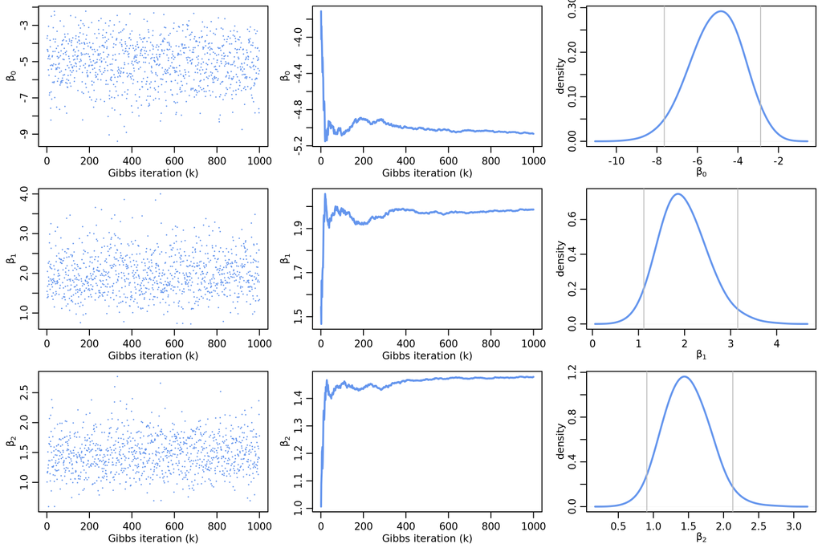

### Gibbs sampling 2 , refer to (Hoff, 2009, Ch.12)

```r
#### probit regression
## setup
 set.seed(123)
 beta<-rep(0,p)
 z<-qnorm(rank(Resp,ties.method="random")/(n+1)) # random initial Z
# mu<-0 ; sigma<-100
## MCMC
gibbs2<-matrix(NA,size,p) ; Z<-matrix(NA,size,n) ; ac<-0
for(m in 1:M) {
  #update beta
  beta<- V%*%( t(X)%*%z ) + cholV%*%rnorm(p)  # ???

  #update z
  ez<-X%*%beta
  u<-runif(n,0,1)
  z<- ez + qnorm(ifelse(Resp==1,u+(1-u)*pnorm(0,ez,1),u*pnorm(0,ez,1)))

  #help mixing
c<-rnorm(1,0,n^(-1/3))  #  sd responding the sample size ????
zp<- z+c
lhr <-  sum(dnorm(zp,ez,100,log=T) - dnorm(z,ez,100,log=T) )
if(log(runif(1))<lhr) { z<-zp ; ac<-ac+1 }
  if(m%%step==0 & m>burnin)
  {
    gibbs2[(m-burnin)/step,]<-  beta
    Z[(m-burnin)/step,]<- z
  }
}
```

Plot Gibbs 2

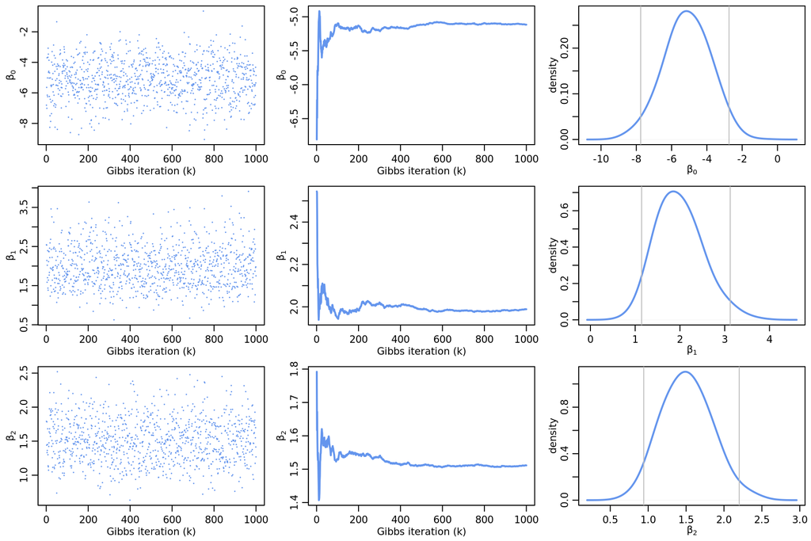

## t link

$\boldsymbol{\beta|y,Z,\lambda,\nu}\sim N_k(\boldsymbol{\hat\beta_{Z,\lambda}},(\mathbf{X'WX})^{-1}); \quad\boldsymbol{\hat\beta_{Z,\lambda}}=(\mathbf{X'WX})^{-1}\mathbf{X'WZ},\ \mathbf{W}=\mathrm{diag}(\lambda_i)$

```r
lambda <- rep(1,n)
w <- diag(lambda)
z<-qnorm(rank(Resp,ties.method="random")/(n+1)) # random initial Z
(beta <- as.vector(solve(t(X)%*%w%*%X)%*%t(X)%*%w%*%z))
```

```
## [1] -1.5265328189  0.4972470138  0.5014871944
```

```r
(ez <- as.vector(X %*% beta))
```

```
##  [1]  0.72700806754  0.76045277128  0.34874393424 -0.40136676702  0.47602381407  0.57674527100 -0.85206921486 -0.12703287331 -0.70289511072 -0.85334126902 -0.84288750708  0.12604282316  0.27627697244  0.33807816327  0.72697942028  0.43957431160  0.86703713626 -0.39426847716 -0.14963646941  0.2711…
```

Generating Z

$Z_i|\boldsymbol{y,\beta,\lambda}\sim N(\mathbf{x}_i^T\boldsymbol{\beta},\lambda_i^{-1})$ truncated by 0 at the $\begin{cases}\text{left if}&y_i=1\\\text{right if}&y_i=0\end{cases}$

```r
set.seed(123); u<-runif(n,0,1)
(z<- ez + qnorm(ifelse(Resp==1,u+(1-u)*pnorm(0,ez,lambda^(-1)),u*pnorm(0,ez,lambda^(-1)))))
```

```
##  [1]  0.611463873754  1.737056214247  0.664475887184  1.346416368230  2.219111657530  0.094350587381 -1.043683135241 -0.148804939766 -0.908612642527 -1.193728100913 -0.117784106125 -0.701615821800 -0.351595547365  0.950152305144  0.238199545190  1.937279159460  0.591790218964  0.039826496487 -1.0…
```

$\boldsymbol{\lambda_{1:N}|y,Z,\beta,\nu}\sim Gamma(\frac{\nu+1}{2},\frac{2}{\nu+(Z_i-\mathbf{x}_i^T\boldsymbol{\beta})^2})$

```r
nu <- 8; set.seed(123)
for(i in 1:n){
lambda[i] <- rgamma(1,shape = (nu+1)/2,rate = ((nu+(z-X %*% beta)^2)/2)[i] )
}
w <- diag(lambda)
```

$\boldsymbol{\hat\beta_Z}=(\mathbf{X}^TW\mathbf{X})^{-1}\mathbf{X}^TW\mathbf{Z}$

```r
t(solve(t(X)%*%w%*%X)%*%t(X)%*%w%*%z) # New E[Beta]
```

```
##                            Vol         Rate
## [1,] -1.887188146 0.8185281696 0.5902801679
```

```r
solve(t(X)%*%w%*%X)                   #     V[Beta]
```

```
##                               Vol           Rate
##       0.3366361226 -0.10229119878 -0.09718616990
## Vol  -0.1022911988  0.05142780032  0.01851338356
## Rate -0.0971861699  0.01851338356  0.04133537027
```

```r
lambdavec <- rgamma(n,1,1)
prod.nu <- function(nu,lambdavec){
  n <- length(lambdavec)
  cnu <- (gamma(nu/2)*((nu/2)^(nu/2)))^(-1) # ^(-n)
  prod(cnu * lambdavec^(nu/2-1) * exp(-nu*lambdavec/2)) #
}

prod.nuvec <- Vectorize(prod.nu,vectorize.args = "nu")
nuprobs <- prod.nuvec(1:20,lambda)

sample(1:20,1,prob =nuprobs[1:20])
```

```
## [1] 1
```

```r
M <- 25000; burnin <- 5000; step <- 20; size <- (M-burnin)/step
set.seed(123)

gibbs3 <- matrix(NA,ncol=p,nrow=size); Z<-matrix(NA,size,n)
for(m in 1:M){  #Gibbs Sampler

  #update z
ez<-(X%*%beta)
# Truncated 1
u<-runif(n,0,1)
z<- ez + qnorm(ifelse(Resp==1,u+(1-u)*pnorm(0,ez,lambda^(-1/2)),u*pnorm(0,ez,lambda^(-1/2))))

# Update beta 1
beta <- mvrnorm(1, t(solve(t(X)%*%w%*%X)%*%t(X)%*%w%*%z)*n/(n+1), solve(t(X)%*%w%*%X)*n/(n+1)) # without n/(n+1)
# Update beta 2
# beta <- mvrnorm(1, V%*%(t(X)%*%z), V) # draw beta from Normal
# Update beta 3
# beta<- V%*%(t(X)%*%z)+cholV%*%rnorm(p)

  #update lambda
for(i in 1:n){
lambda[i] <- rgamma(1,shape = (nu+1)/2 , rate = ((nu+(z-X %*% beta)^2)/2)[i] )
}
# lambda <- rgamma(n,shape = (nu+1)/2 , rate = ((nu+(z-X %*% beta)^2)/2) )

w <- diag(lambda)

 # Update nu

if(m%%step==0 & m>burnin) { gibbs3[(m-burnin)/step,] <- t(beta); Z[(m-burnin)/step,]<- z}
}
```

Plot Gibbs 3

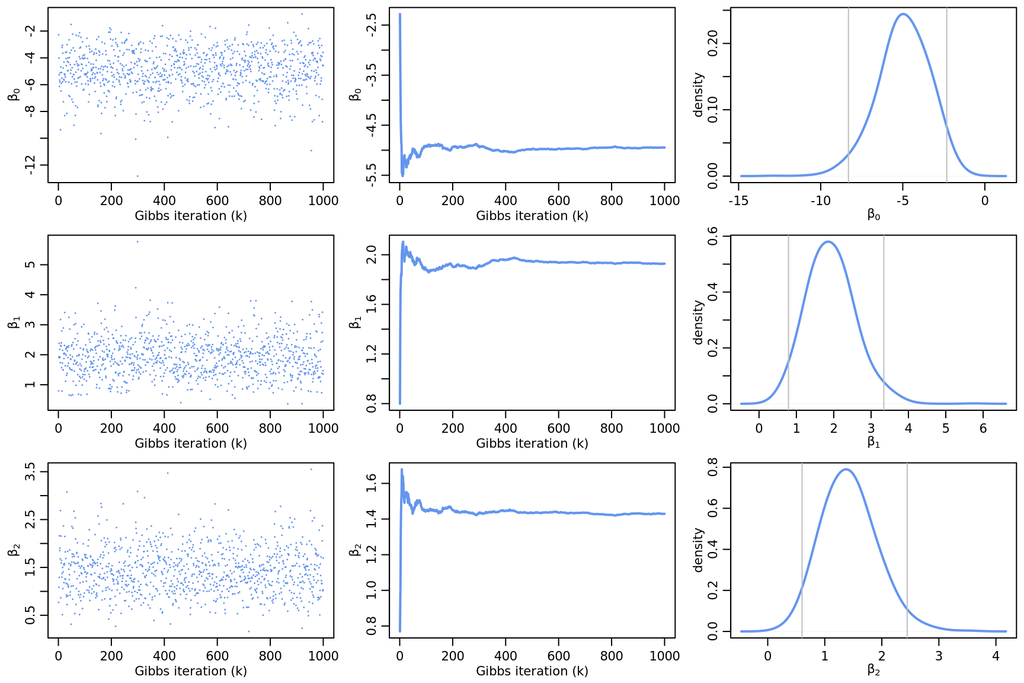

$\boldsymbol{\hat\beta}\approx\frac1m\sum_{i=1}^m(\boldsymbol{\beta|Z^{(i)}})$

```r
(g1 <- colMeans(gibbs1,na.rm = T))
```

```
## [1] -5.067231950  1.985793673  1.478392240
```

```r
(g2<-apply(gibbs2,2,mean))
```

```
## [1] -5.116011976  1.988678931  1.511336141
```

```r
(g3<-apply(gibbs3,2,mean))
```

```
## [1] -4.945966817  1.927945913  1.429397899
```

```r
g1.sd<- apply(gibbs1,2,sd,na.rm = T)
g2.sd<-apply(gibbs2,2,sd)
g3.sd<-apply(gibbs3,2,sd)
```

- Marginal Effects

$p_i=\mathbf{x}_i^T\boldsymbol{\beta}$

$\beta_{marg}=\overline{\phi(p_i)}\boldsymbol{\beta}$

```r
(g1.marg <- mean(dnorm(X %*% t(gibbs1)))*g1)
```

```
## [1] -1.0406828244  0.4078324002  0.3036248245
```

```r
(g2.marg <- mean(dnorm(X %*% t(gibbs2)))*g2)
```

```
## [1] -1.0265827550  0.3990497883  0.3032658303
```

```r
(g3.marg <- mean(dnorm(X %*% t(gibbs3)))*g3)
```

```
## [1] -1.1289246101  0.4400566499  0.3262622911
```

### Rank likelihood regression

```r
source("rlreg.R")
rfit<-treg(Resp,X)
```

```r
(rl <- apply(rfit$BETA,2,mean)) # function(x) c(mean(x),sd(x)))
```

```
## [1] -5.003214359  1.902114803  1.402585993
```

```r
(rl.sd <- apply(rfit$BETA,2,sd))
```

```
## [1] 2.4019106539 0.4966275128 0.3067295935
```

```r
(rl.marg <- mean(dnorm(X %*% t(rfit$BETA)))*rl)
```

```
## [1] -0.6998954549  0.2660852424  0.1962065766
```

### GLM

```r
fit.probit.glm <- glm(Resp~Vol+Rate,family=binomial(link="probit"))
glm.p<- coef(fit.probit.glm)
glm.p.sd <- summary(fit.probit.glm)$coef[,2] # sqrt(diag(vcov(fit.probit.glm)))
# fit.probit.lm <- lm(Resp~Vol+Rate)
# fit.logit.glm <- glm(Resp~Vol+Rate,family=binomial(link="logit"))
#comp <- fits.compare(fit.probit.lm, fit.probit.glm, fit.logit.glm)
#comp
#plot(comp)
(glm.p.marg <- mean(dnorm(X %*% glm.p))*glm.p)
```

```
##   (Intercept)           Vol          Rate
## -1.1243955777  0.4493721022  0.3235036088
```

### nimble

- Code 1

```r
code <- nimbleCode({
  beta0 ~ dnorm(0, sd = 100)
  beta1 ~ dnorm(0, sd = 100)
  beta2 ~ dnorm(0, sd = 100)
#  sigma ~ dunif(0, 100)
  for(i in 1:n) {
    y[i] ~ dbern(p[i])
    probit(p[i])  <- beta0 + beta1*x1[i] + beta2*x2[i] # sd = sigma

  }
})
## extract data for two predictors and center for better MCMC performance
x1 <- Vol #- mean(Vol)
x2 <- Rate # - mean(Rate)

constants <- list(n = n)
data <- list(y = Resp, x1 = x1, x2 = x2)
inits <- list(beta0 = -0.5, beta1 = 0.1, beta2 = 0.1) # beta0 =mean(Resp), sigma = 1
model <- nimbleModel(code, constants = constants, data = data, inits = inits) # build model
```

```r
mcmc.out <- nimbleMCMC(code = code, constants = constants,
                       data = data, inits = inits,
                       nchains = 4, niter = 2000,
                       summary = TRUE, WAIC = T,
                       monitors = c('beta0','beta1','beta2')) #,'sigma'
## |-------------|-------------|-------------|-------------|
## |-------------------------------------------------------|
## |-------------|-------------|-------------|-------------|
## |-------------------------------------------------------|
## |-------------|-------------|-------------|-------------|
## |-------------------------------------------------------|
## |-------------|-------------|-------------|-------------|
## |-------------------------------------------------------|
names(mcmc.out)
```

```
## [1] "samples" "summary" "WAIC"
```

```r
nimble.p <- mcmc.out$summary$all.chains[,1]
nimble.p.sd <- mcmc.out$summary$all.chains[,3]
```

```r
# nimble.sample<- rbind(mcmc.out$samples$chain1[1901:2000,],mcmc.out$samples$chain2[1901:2000,],
#                       mcmc.out$samples$chain3[1901:2000,],mcmc.out$samples$chain4[1901:2000,])
(nimble.p.marg <- mean(dnorm(X %*% (nimble.p)))*nimble.p)
```

```
##        beta0        beta1        beta2
## -1.079920561  0.435148282  0.311829581
```

- Code 2 Use `inprod`

```r
code <- nimbleCode({
  beta0 ~ dnorm(0, sd = 100)
  for(j in 1:k)
    beta[j] ~ dnorm(0, sd = 100)
#  sigma ~ dunif(0, 100)
  for(i in 1:n) {
  probit(p[i]) <- beta0 + inprod(beta[1:k], x[i, 1:k]) #, sd = sigma)
    y[i] ~ dbern(p[i])
  }
})

k <- 2
# cX <- sweep(finney[,1:2], 2, colMeans(finney[,1:2]))  # center for better MCMC performance

constants <- list(n = n, k = 2, x =finney[,1:2]) # cX
data <- list(y = Resp)
inits <- list(beta0 = -0.5, beta = rep(0, k), sigma = 0.5)
model <- nimbleModel(code, constants = constants, data = data, inits = inits)
```

```r
mcmc.out <- nimbleMCMC(code = code, constants = constants,
                       data = data, inits = inits,
                       nchains = 2, niter = 1000,
                       summary = TRUE, WAIC = T,
                       monitors = c('beta0','beta')) # ,'beta2','sigma'
## |-------------|-------------|-------------|-------------|
## |-------------------------------------------------------|
## |-------------|-------------|-------------|-------------|
## |-------------------------------------------------------|
names(mcmc.out)
```

```
## [1] "samples" "summary" "WAIC"
```

```r
mcmc.out$summary$all.chains
```

```
##                 Mean       Median      St.Dev.     95%CI_low    95%CI_upp
## beta[1]  1.854973583  1.864334529 0.7217560493  0.4194973201  3.218455718
## beta[2]  1.323566109  1.300963964 0.5036035140  0.3838111003  2.325701527
## beta0   -4.583887520 -4.664455054 1.6913421198 -7.6682722497 -1.271849285
```

```r
mcmc.out$WAIC
```

```
## [1] 37.96846374
```

- Code 3 Use Matrix Algebra

```r
code <- nimbleCode({
     beta0 ~ dnorm(0, sd = 100)
     beta[1:k] ~ dmnorm(zeros[1:k], omega[1:k, 1:k])
#     sigma ~ dunif(0, 100)
     linpred[1:n] <- (x[1:n, 1:k] %*% beta[1:k])[1:n,1]
     for(i in 1:n) {
     probit(p[i]) <-  beta0 + linpred[i,1]   #~ dnorm(, sd = sigma)
     y[i] ~ dbern(p[i])
       }
})

constants <- list(n = n, k = k, x = finney[,1:2], zeros = rep(0, k), omega = 0.0001 * diag(k))
data <- list(y = Resp)
inits <- list(beta0 = -0.5, beta = rep(0, k), sigma = 0.5)
model <- nimbleModel(code, constants = constants, data = data, inits = inits)
```

```r
mcmcConf <- configureMCMC(model)
## ===== Monitors =====
## thin = 1: beta0, beta
## ===== Samplers =====
## RW sampler (3)
##   - beta0
##   - beta[]  (2 elements)
mcmcConf$printSamplers()
```

```
## [1] RW sampler: beta0
## [2] RW sampler: beta[1]
## [3] RW sampler: beta[2]
```

### brms

```r
brms.p <- brm(Resp ~ Vol + Rate, data =finney, family = bernoulli("probit"),silent = T, refresh=0) # probit_approx
```

```r
summary(brms.p)
```

```
##  Family: bernoulli
##   Links: mu = probit
## Formula: Resp ~ Vol + Rate
##    Data: finney (Number of observations: 39)
## Samples: 4 chains, each with iter = 2000; warmup = 1000; thin = 1;
##          total post-warmup samples = 4000
##
## Population-Level Effects:
##           Estimate Est.Error l-95% CI u-95% CI Rhat Bulk_ESS Tail_ESS
## Intercept    -5.61      1.57    -8.96    -2.84 1.00     1779     1752
## Vol           2.24      0.69     1.01     3.73 1.00     1927     2066
## Rate          1.62      0.49     0.74     2.69 1.00     1945     2062
##
## Samples were drawn using sampling(NUTS). For each parameter, Bulk_ESS
## and Tail_ESS are effective sample size measures, and Rhat is the potential
## scale reduction factor on split chains (at convergence, Rhat = 1).
```

```r
brm.p <- fixef(brms.p)[,1]
brm.p.sd <- fixef(brms.p)[,2]
```

```r
(brm.p.marg <- mean(dnorm(X %*% brm.p))*brm.p)
```

```
##     Intercept           Vol          Rate
## -1.1627031634  0.4647253280  0.3357292676
```

### Comparing the results

```r
par.p<- cbind(rl,g1,g3,glm.p,g2,nimble.p,brm.p)
rownames(par.p) <- c("Beta0","Beta1","Beta2")
pander::pander(round((par.p),4))
```

|  | rl | g1 | g3 | glm.p | g2 | nimble.p | brm.p |
| --- | --- | --- | --- | --- | --- | --- | --- |
| **Beta0** | -5.003 | -5.067 | -4.946 | -5.06 | -5.116 | -4.605 | -5.611 |
| **Beta1** | 1.902 | 1.986 | 1.928 | 2.022 | 1.989 | 1.855 | 2.243 |
| **Beta2** | 1.403 | 1.478 | 1.429 | 1.456 | 1.511 | 1.33 | 1.62 |

```r
par.p.sd<- rbind(g1.sd,g2.sd,g3.sd,rl.sd,glm.p.sd, nimble.p.sd,brm.p.sd)
colnames(par.p.sd) <- c("Beta0","Beta1","Beta2")
pander::pander(round(t(par.p.sd),4))
```

|  | g1.sd | g2.sd | g3.sd | rl.sd | glm.p.sd | nimble.p.sd | brm.p.sd |
| --- | --- | --- | --- | --- | --- | --- | --- |
| **Beta0** | 1.221 | 1.276 | 1.533 | 2.402 | 1.553 | 1.743 | 1.572 |
| **Beta1** | 0.5099 | 0.5158 | 0.6414 | 0.4966 | 0.683 | 0.7414 | 0.6934 |
| **Beta2** | 0.3135 | 0.3232 | 0.4744 | 0.3067 | 0.4618 | 0.532 | 0.4927 |

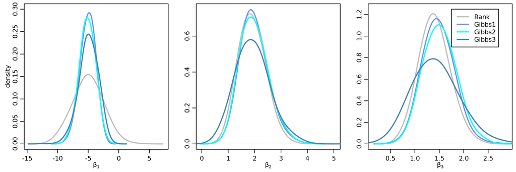

[figure not shown]

## Logit Binary

### gibbs

$$\begin{align}
\boldsymbol{\omega_i|\beta} &\sim PG(1,\boldsymbol{|X'_{i,1:p}\beta|}),i=1:n \\
\boldsymbol{\beta}&\sim N_p(0,\boldsymbol{\sigma^2}I=diag_p(100))\\
Pr(\boldsymbol{\beta|Y,\omega})&=\phi_p(0,\boldsymbol{\sigma^2I)\phi_n(\eta|X'\beta,\Omega^{-1}}) & where \boldsymbol{\Omega}=diag_n(\mathbf{\omega_i}); \boldsymbol{\eta}=\mathbf{\Omega^{-1}}(\mathbf{Y_{1:n}}-\frac12)\\
&=\exp{[-\frac12\boldsymbol{\beta'\sigma^2I\beta}]}\exp{[-\frac12\boldsymbol{(\eta-X\beta)'\Omega(\eta-X\beta)}]}\\
&=\exp{[-\frac12(\boldsymbol{\beta'(\sigma^2I+X'\Omega X)\beta}-2\boldsymbol{\beta'X'\Omega\eta+\eta'\eta})]} & let \underset{p\cdot p}{\boldsymbol{\Sigma}}=\boldsymbol{(\sigma^{2}I+X'\Omega X)^{-1}}\\
&\propto\exp{[\boldsymbol{-\frac12\Sigma^{-1}(\beta'I\beta-2\beta'\Sigma X'\Omega\eta)}]}\\
&\propto\exp{[\boldsymbol{-\frac12(\beta-\Sigma X'\Omega\eta)'\Sigma^{-1}(\beta-\Sigma X'\Omega\eta)}]}\\
\boldsymbol{\beta|Y,\omega}&\sim N_p(\boldsymbol{\underset{(p\cdot p)}{\Sigma} \underset{(p\cdot n)}{X'}\underset{(n\cdot n)}{\Omega}\underset{(n\cdot 1)}{\eta}},\boldsymbol{\Sigma})\\
\end{align}$$

```r
beta.ini=runif(dim(X)[2],-3,3)

w.cond <- function(beta){
  xb=abs(X%*%beta) # as.vector(X%*%beta)
  W=rpg.devroye(num=n, h=1, z=xb)
  return(W)
}
w.ini=w.cond(beta.ini)

beta.cond = function(y,w,varbeta=100){
  matbetapr=diag(rep(1/varbeta,p))
  OMG=diag(w)
  OMGinv=diag(1/w)
  eta=OMGinv%*%(y-0.5)
  varmat=chol2inv(chol(matbetapr+t(X)%*%OMG%*%X)) # =solve(), faster
  meanvec = varmat%*%(t(X)%*%OMG%*%eta)
  beta=rmvnorm(1, mean = meanvec, sigma = varmat)
  return(beta)
}
beta.ini=beta.cond(y=Resp,w=w.ini)
```

```r
M <- 25000
W=matrix(NA,nrow=M,ncol=n)
Beta=matrix(NA,nrow=(M+1),ncol=p)
Beta[1,]=beta.ini
for(i in 1:M){
  W[i,] = w.cond(Beta[i,])
  Beta[(i+1),]=beta.cond(Resp,W[i,])
}
```

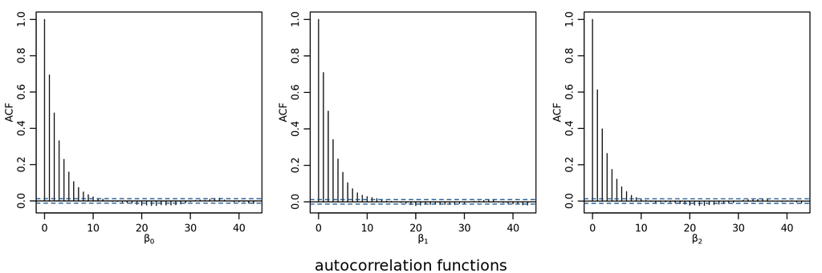

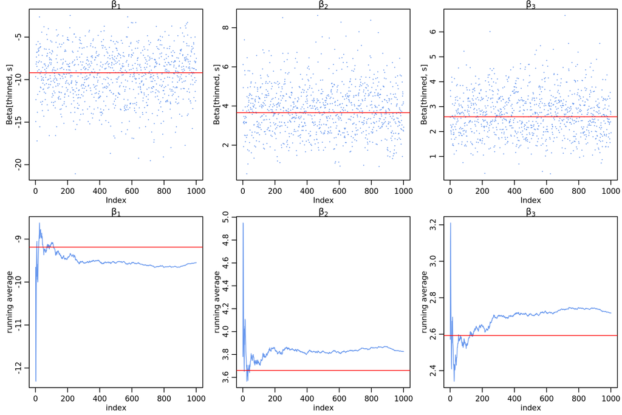

```r
W=matrix(NA,nrow=M,ncol=n)
Beta=matrix(NA,nrow=(M+1),ncol=p)
Beta[1,]=c(-9.186610938,3.660409960,2.592717380)
for(i in 1:M){
  W[i,] = w.cond(Beta[i,])
  Beta[(i+1),]=beta.cond(Resp,W[i,])
}
```

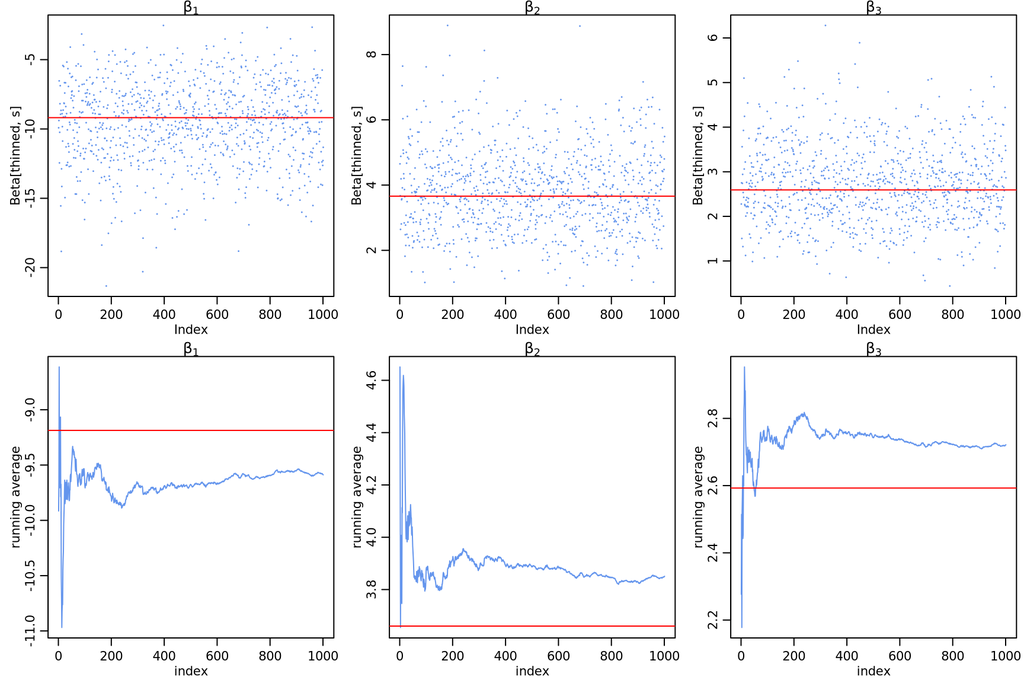

```r
(g.PG.par <- data.frame(PostMean=colMeans(Beta[thinned,]),
                      PostMedian=apply(Beta[thinned,],2,quantile,probs=0.5),
                      ll.95=apply(Beta[thinned,],2,quantile,probs=0.025),
                      ul.95=apply(Beta[thinned,],2,quantile,probs=0.975)))
```

```
##       PostMean   PostMedian         ll.95        ul.95
## 1 -9.588448477 -9.308427490 -15.841253970 -4.638158261
## 2  3.851012147  3.779774728   1.700515554  6.412826690
## 3  2.721354430  2.666849379   1.195393485  4.541957355
```

```r
g.PG <- g.PG.par[,1]
```

```r
(g.PG.marg <- mean(dlogis(X %*% g.PG))*g.PG)
```

```
## [1] -1.1752781041  0.4720273844  0.3335626492
```

### brms

```r
brms.l <- brm(Resp ~ Vol + Rate, data =finney, family = bernoulli("logit"),silent = T, refresh=0)
```

```r
summary(brms.l)
```

```
##  Family: bernoulli
##   Links: mu = logit
## Formula: Resp ~ Vol + Rate
##    Data: finney (Number of observations: 39)
## Samples: 4 chains, each with iter = 2000; warmup = 1000; thin = 1;
##          total post-warmup samples = 4000
##
## Population-Level Effects:
##           Estimate Est.Error l-95% CI u-95% CI Rhat Bulk_ESS Tail_ESS
## Intercept   -11.03      3.63   -18.81    -4.99 1.01     1379     1350
## Vol           4.41      1.54     1.93     7.84 1.01     1396     1575
## Rate          3.10      1.05     1.34     5.41 1.00     1504     1606
##
## Samples were drawn using sampling(NUTS). For each parameter, Bulk_ESS
## and Tail_ESS are effective sample size measures, and Rhat is the potential
## scale reduction factor on split chains (at convergence, Rhat = 1).
```

```r
brm.l <- fixef(brms.l)[,1]
brm.l.sd <- fixef(brms.l)[,2]
```

```r
brm.sample <- data.frame()
for (i in 1:4) {
brm.sample <- rbind(brm.sample,data.frame(brms.l$fit@sim$samples[[i]])[1901:2000,1:3])
}
prob.l<-  mean(X %*% t(brm.sample))
(brm.l.marg <-prob.l*(1-prob.l)*brm.l)
```

```
##     Intercept           Vol          Rate
## -1.9113568209  0.7642003849  0.5372967733
```

```r
(brm.l.marg <- mean(dlogis(X %*% t(brm.sample)))*brm.l)
```

```
##     Intercept           Vol          Rate
## -1.2464574294  0.4983597186  0.3503885552
```

```r
(brm.l.marg <- mean(dlogis(X %*% brm.l))*brm.l)
```

```
##     Intercept           Vol          Rate
## -1.2398619498  0.4957227080  0.3485345163
```

```r
inv_logit <- function(x) 1 / (1 + exp(-x))
fit.brms2 <- brm(bf(Resp ~ inv_logit(eta),
                     eta ~ Vol + Rate, nl = T),
  data = finney, family = bernoulli("identity"),
  prior = prior(normal(0, 100), nlpar = "eta"),silent = T, refresh=0
)

fit.brms3 <- brm(
  bf(Resp ~ guess + (1 - guess) * inv_logit(eta),
    eta ~  Vol + Rate, guess ~ 1, nl = T),
  data = finney, family = bernoulli("identity"),
  prior = c(
    prior(normal(0, 100), nlpar = "eta"),
    prior(beta(1, 1), nlpar = "guess", lb = 0, ub = 1)
  ),silent = T, refresh=0
)
summary(fit.brms2)
summary(fit.brms3)
```

### nimble

```r
## define the model
code <- nimbleCode({
    beta0 ~ dnorm(0, sd = 100)
    beta1 ~ dnorm(0, sd = 100)
    beta2 ~ dnorm(0, sd = 100)
#    sigma_RE ~ dunif(0, 1000)
    for(i in 1:n) {
#        beta2[i] ~ dnorm(0, sd = sigma_RE)
        logit(p[i]) <- beta0 + beta1 * x1[i] + beta2 *x2[i]
        y[i] ~ dbern(p[i])
    }
})
## constants, data, and initial values
x1 <- Vol # - mean(Vol)
x2 <- Rate # - mean(Rate)
constants <- list(n = n, x1 = x1, x2 = x2)
data <- list(y = Resp)
inits <- list(beta0 = -0.5, beta1 = 0.1, beta2 = .1)

## create the model object
Rmodel <- nimbleModel(code=code, constants=constants, data=data, inits=inits, check = FALSE)
```

```r
Rmcmc <- buildMCMC(Rmodel)
#Compile the model and MCMC algorithm
Cmodel <- compileNimble(Rmodel)
Cmcmc <- compileNimble(Rmcmc, project = Rmodel)
#Execute MCMC algorithm and extract samples
Cmcmc$run(1000)
samples <- as.matrix(Cmcmc$mvSamples)
```

```r
mcmcConf <- configureMCMC(Rmodel)
mcmcConf$printSamplers()
```

```r
mcmc.out <- nimbleMCMC(code = code, constants = constants,
                       data = data, inits = inits,
                       nchains = 4, niter = 2000,
                       summary = TRUE, WAIC = T,
                       monitors = c('beta0','beta1','beta2')) #,'sigma''sigma_RE',
## |-------------|-------------|-------------|-------------|
## |-------------------------------------------------------|
## |-------------|-------------|-------------|-------------|
## |-------------------------------------------------------|
## |-------------|-------------|-------------|-------------|
## |-------------------------------------------------------|
## |-------------|-------------|-------------|-------------|
## |-------------------------------------------------------|
```

```r
nimble.l <- mcmc.out$summary$all.chains[,1]
nimble.l.sd <- mcmc.out$summary$all.chains[,3]
```

```r
nimble.sample<- rbind(mcmc.out$samples$chain1[1901:1000,],mcmc.out$samples$chain2[1901:1000,],
                      mcmc.out$samples$chain3[1901:1000,],mcmc.out$samples$chain4[1901:1000,])
prob.l<-  mean(X %*% t(nimble.sample))
(glm.l.marg <-prob.l*(1-prob.l)*nimble.l)
```

```
##         beta0         beta1         beta2
## -1.8645124864  0.7622078319  0.5186020843
```

```r
(nimble.l.marg <- mean(dlogis(X %*% nimble.l))*nimble.l)
```

```
##         beta0         beta1         beta2
## -1.1888558430  0.4860011618  0.3306725606
```

### GLM

```r
fit.l.glm <- glm(Resp~Vol+Rate,family=binomial(link="logit"))
glm.l<- coef(fit.l.glm)
glm.l.sd <- summary(fit.l.glm)$coef[,2] # sqrt(diag(vcov(fit.probit.glm)))
```

```r
prob.l<-  mean(X %*% glm.l)
(glm.l.marg <-prob.l*(1-prob.l)*glm.l)
```

```
##   (Intercept)           Vol          Rate
## -1.4012784522  0.5583401362  0.3954797936
```

```r
(glm.l.marg <-mean(dlogis(X %*% glm.l))*glm.l)
```

```
##   (Intercept)           Vol          Rate
## -1.1637740204  0.4637063705  0.3284494303
```

- Another method

```r
library(mfx)
(mfx.l <- logitmfx(Resp~Vol+Rate,finney))
```

```
## Call:
## logitmfx(formula = Resp ~ Vol + Rate, data = finney)
##
## Marginal Effects:
##           dF/dx  Std. Err.       z     P>|z|
## Vol  0.90708053 0.32610707 2.78154 0.0054101 **
## Rate 0.64249728 0.22465027 2.85999 0.0042366 **
## ---
## Signif. codes:  0 '***' 0.001 '**' 0.01 '*' 0.05 '.' 0.1 ' ' 1
```

```r
mfx.l$mfxest[,1]/2
```

```
##         Vol        Rate
## 0.453540264 0.321248641
```

### mlogit

```r
finney.mlogit <-dfidx(finney, choice = "Resp", shape='wide') # varying = c(1:2),
#finney.mlogit <- mlogit.data(finney, choice='Resp', shape='wide', varying=1:2) #
fit.mlogit <- mlogit(Resp~1|(Vol+Rate),finney.mlogit, probit=F) #|0 ,reflevel=5,seed=20,R=100
# fit.mlogit <- mlogit(Resp~Vol+Rate,finney.mlogit, probit=T)
mlogit<- coef(fit.mlogit)
mlogit.sd <- sqrt(diag(vcov(fit.mlogit)))
mlogit.marg <- rep(NA,3)
mlogit.marg[2] <- colMeans(effects(fit.mlogit, covariate = "Vol", data = finney.mlogit))[2] #type = "ar",
mlogit.marg[3] <- colMeans(effects(fit.mlogit, covariate = "Rate",  data = finney.mlogit))[2]
```

### Comparing the results

|  | brm.l | nimble.l | g.PG | glm.l | mlogit |
| --- | --- | --- | --- | --- | --- |
| **Beta0** | -11.03 | -9.845 | -9.588 | -9.187 | -9.187 |
| **Beta1** | 4.411 | 4.024 | 3.851 | 3.66 | 3.66 |
| **Beta2** | 3.101 | 2.738 | 2.721 | 2.593 | 2.593 |

|  | brm.l.sd | nimble.l.sd | glm.l.sd | mlogit.sd |
| --- | --- | --- | --- | --- |
| **Beta0** | 3.63 | 3.71 | 3.104 | 3.104 |
| **Beta1** | 1.543 | 1.577 | 1.333 | 1.333 |
| **Beta2** | 1.051 | 1.069 | 0.9058 | 0.9058 |

$p_i=\mathbf{x}_i^T\boldsymbol{\beta}$; $\beta_{marg}=\overline{\phi(p_i)}\boldsymbol{\beta}$; $\beta_{marg}=\overline{logit(p_i)}\boldsymbol{\beta}$; $\beta_{marg}=\bar p(1-\bar p))\boldsymbol{\beta}$

|  | Beta0 | Beta1 | Beta2 |
| --- | --- | --- | --- |
| **rl.marg** | -0.6999 | 0.2661 | 0.1962 |
| **nimble.p.marg** | -1.08 | 0.4351 | 0.3118 |
| **g1.marg** | -1.041 | 0.4078 | 0.3036 |
| **g2.marg** | -1.027 | 0.399 | 0.3033 |
| **g3.marg** | -1.129 | 0.4401 | 0.3263 |
| **glm.p.marg** | -1.124 | 0.4494 | 0.3235 |
| **glm.l.marg** | -1.164 | 0.4637 | 0.3284 |
| **mlogit.marg** | NA | 0.4637 | 0.3284 |
| **g.PG.marg** | -1.175 | 0.472 | 0.3336 |
| **nimble.l.marg** | -1.189 | 0.486 | 0.3307 |
| **brm.p.marg** | -1.163 | 0.4647 | 0.3357 |
| **brm.l.marg** | -1.24 | 0.4957 | 0.3485 |

### `glmer`

```r
# From https://data.princeton.edu/
glmer.p <- glmer(Resp~Vol+(1|Rate), family=binomial(link = "probit"))#, nAGQ = 12, REML=FALSE
summary(glmer.p)
## Generalized linear mixed model fit by maximum likelihood (Laplace Approximation) ['glmerMod']
##  Family: binomial  ( probit )
## Formula: Resp ~ Vol + (1 | Rate)
##
##      AIC      BIC   logLik deviance df.resid
##     52.7     57.7    -23.3     46.7       36
##
## Scaled residuals:
##        Min         1Q     Median         3Q        Max
## -1.8634858 -0.6797333  0.1055860  0.8242038  1.2608467
##
## Random effects:
##  Groups Name        Variance  Std.Dev.
##  Rate   (Intercept) 0.2050805 0.4528581
## Number of obs: 39, groups:  Rate, 31
##
## Fixed effects:
##               Estimate Std. Error z value Pr(>|z|)
## (Intercept) -1.1403308  0.6268984 -1.8190 0.068911 .
## Vol          0.9253519  0.4870796  1.8998 0.057460 .
## ---
## Signif. codes:  0 '***' 0.001 '**' 0.01 '*' 0.05 '.' 0.1 ' ' 1
##
## Correlation of Fixed Effects:
##     (Intr)
## Vol -0.920
```

```r
glmer.l <- glmer(Resp~Vol+(1|Rate), family=binomial(link = "logit"))
summary(glmer.l)
## Generalized linear mixed model fit by maximum likelihood (Laplace Approximation) ['glmerMod']
##  Family: binomial  ( logit )
## Formula: Resp ~ Vol + (1 | Rate)
##
##      AIC      BIC   logLik deviance df.resid
##     52.7     57.7    -23.4     46.7       36
##
## Scaled residuals:
##        Min         1Q     Median         3Q        Max
## -1.8141424 -0.6530319  0.1408086  0.7822189  1.2134724
##
## Random effects:
##  Groups Name        Variance  Std.Dev.
##  Rate   (Intercept) 0.7651884 0.8747505
## Number of obs: 39, groups:  Rate, 31
##
## Fixed effects:
##               Estimate Std. Error  z value Pr(>|z|)
## (Intercept) -1.9257428  1.1449681 -1.68192 0.092585 .
## Vol          1.5761011  0.9109241  1.73022 0.083591 .
## ---
## Signif. codes:  0 '***' 0.001 '**' 0.01 '*' 0.05 '.' 0.1 ' ' 1
##
## Correlation of Fixed Effects:
##     (Intr)
## Vol -0.930
```

## Ordinal-Panel

```r
library(foreign)
Panel101 <- read.dta("https://dss.princeton.edu/training/Panel101.dta")
```

```r
kable(summary(Panel101))
```

|  | country | year | y | y_bin | x1 | x2 | x3 | opinion | op |
| --- | --- | --- | --- | --- | --- | --- | --- | --- | --- |
|  | A:10 | Min. :1990.0 | Min. :-7863482880 | Min. :0.0 | Min. :-0.5675749 | Min. :-1.6217614 | Min. :-1.16538668 | Str agree:20 | Min. :0.0 |
|  | B:10 | 1st Qu.:1992.0 | 1st Qu.: 246571560 | 1st Qu.:1.0 | 1st Qu.: 0.3289598 | 1st Qu.:-1.2156489 | 1st Qu.:-0.07931513 | Agree :15 | 1st Qu.:0.0 |
|  | C:10 | Median :1994.5 | Median : 1897897536 | Median :1.0 | Median : 0.6412617 | Median :-0.4621431 | Median : 0.51419075 | Disag :19 | Median :0.5 |
|  | D:10 | Mean :1994.5 | Mean : 1845072181 | Mean :0.8 | Mean : 0.6480006 | Mean : 0.1338694 | Mean : 0.76185101 | Str disag:16 | Mean :0.5 |
|  | E:10 | 3rd Qu.:1997.0 | 3rd Qu.: 3372262464 | 3rd Qu.:1.0 | 3rd Qu.: 1.0958428 | 3rd Qu.: 1.6077535 | 3rd Qu.: 1.15486443 | NA | 3rd Qu.:1.0 |
|  | F:10 | Max. :1999.0 | Max. : 8941232128 | Max. :1.0 | Max. : 1.4464116 | Max. : 2.5302765 | Max. : 7.16892195 | NA | Max. :1.0 |
|  | G:10 | NA | NA | NA | NA | NA | NA | NA | NA |

### `nnet`

```r
nnet::multinom(opinion ~ x1 + x2 + x3, data=Panel101)%>%summary()
## # weights:  20 (12 variable)
## initial  value 97.040605
## iter  10 value 89.282410
## final  value 89.067983
## converged
## Call:
## nnet::multinom(formula = opinion ~ x1 + x2 + x3, data = Panel101)
##
## Coefficients:
##             (Intercept)           x1            x2              x3
## Agree     -0.3804366412 0.8586524725 -0.1982031136 -1.018836691828
## Disag     -0.5139610863 0.3347049833  0.1044980252  0.261419255540
## Str disag -1.5476919813 1.8995628294  0.3859729637 -0.007022118473
##
## Std. Errors:
##            (Intercept)           x1           x2           x3
## Agree     0.7792886702 0.9596779169 0.3598598147 0.5184446664
## Disag     0.6276813421 0.8155329795 0.3178694831 0.2696497906
## Str disag 0.8317434934 0.9634219575 0.3424069969 0.3090406978
##
## Residual Deviance: 178.1359669
## AIC: 202.1359669
```

### `brms`

https://kevinstadler.github.io/blog/bayesian-ordinal-regression-with-random-effects-using-brms/

```r
# brm(self ~ age + (1|id), data=d, family=cumulative("logit"), threshold="flexible") #
# Families cumulative, cratio(continuation ratio), sratio(stopping ratio), and acat(adjacent category)
#          support logit, probit, probit_approx, cloglog, and cauchit.
# Families categorical, multinomial, and dirichlet support logit.
# Panel101$y_ord<-match(Panel101[,8],levels(Panel101[,8]))
brm.ord <- brm(opinion ~ x1 + x2 + x3, data=Panel101, family=categorical,silent = T, refresh=0)# , refcat ="Str disag"
```

```r
summary(brm.ord)
```

```
##  Family: categorical
##   Links: muAgree = logit; muDisag = logit; muStrdisag = logit
## Formula: opinion ~ x1 + x2 + x3
##    Data: Panel101 (Number of observations: 70)
## Samples: 4 chains, each with iter = 2000; warmup = 1000; thin = 1;
##          total post-warmup samples = 4000
##
## Population-Level Effects:
##                      Estimate Est.Error l-95% CI u-95% CI Rhat Bulk_ESS Tail_ESS
## muAgree_Intercept       -0.43      0.80    -2.11     1.09 1.00     3344     3091
## muDisag_Intercept       -0.61      0.66    -1.93     0.66 1.00     3525     3351
## muStrdisag_Intercept    -1.72      0.89    -3.53    -0.12 1.00     3042     2641
## muAgree_x1               0.96      0.99    -0.88     3.00 1.00     3299     3269
## muAgree_x2              -0.21      0.37    -0.92     0.50 1.00     2929     3213
## muAgree_x3              -1.12      0.52    -2.22    -0.14 1.00     3056     2932
## muDisag_x1               0.41      0.85    -1.24     2.07 1.00     3528     3288
## muDisag_x2               0.14      0.34    -0.52     0.79 1.00     2997     3149
## muDisag_x3               0.34      0.31    -0.21     0.98 1.00     3125     3063
## muStrdisag_x1            2.13      1.02     0.24     4.22 1.00     3186     2633
## muStrdisag_x2            0.44      0.36    -0.25     1.18 1.00     2927     3133
## muStrdisag_x3           -0.01      0.35    -0.72     0.68 1.00     3081     2505
##
## Samples were drawn using sampling(NUTS). For each parameter, Bulk_ESS
## and Tail_ESS are effective sample size measures, and Rhat is the potential
## scale reduction factor on split chains (at convergence, Rhat = 1).
```

```r
brm.ord.l <- fixef(brm.ord)[,1]
brm.ord.l.sd <- fixef(brm.ord)[,2]
```

### `polr`

```r
polr.p <- polr(opinion ~ x1 + x2 + x3, data=Panel101, Hess=TRUE,method = "probit")
summary(polr.p)
```

```
## Call:
## polr(formula = opinion ~ x1 + x2 + x3, data = Panel101, Hess = TRUE,
##     method = "probit")
##
## Coefficients:
##         Value Std. Error   t value
## x1 0.61525637  0.3383960 1.8181549
## x2 0.15047792  0.1259730 1.1945249
## x3 0.05247143  0.1008939 0.5200655
##
## Intercepts:
##                 Value      Std. Error t value
## Str agree|Agree -0.1224620  0.2855353 -0.4288858
## Agree|Disag      0.4569078  0.2858961  1.5981601
## Disag|Str disag  1.2234648  0.3061002  3.9969415
##
## Residual Deviance: 189.4659772
## AIC: 201.4659772
```

```r
library(erer)
ocME(polr.p)# , x.mean=TRUE
```

```
##    effect.Str agree effect.Agree effect.Disag effect.Str disag
## x1           -0.207       -0.038        0.062            0.183
## x2           -0.051       -0.009        0.015            0.045
## x3           -0.018       -0.003        0.005            0.016
```

```r
polr.l <- polr(opinion ~ x1 + x2 + x3, data=Panel101, Hess=TRUE,method = "logistic")
summary(polr.l)
```

```
## Call:
## polr(formula = opinion ~ x1 + x2 + x3, data = Panel101, Hess = TRUE,
##     method = "logistic")
##
## Coefficients:
##         Value Std. Error   t value
## x1 0.98139603  0.5641136 1.7397134
## x2 0.24935530  0.2086027 1.1953599
## x3 0.09089175  0.1549254 0.5866807
##
## Intercepts:
##                 Value      Std. Error t value
## Str agree|Agree -0.2054266  0.4682027 -0.4387558
## Agree|Disag      0.7369675  0.4696907  1.5690486
## Disag|Str disag  1.9950790  0.5204282  3.8335334
##
## Residual Deviance: 189.6381709
## AIC: 201.6381709
```

```r
ocME(polr.l)
```

```
##    effect.Str agree effect.Agree effect.Disag effect.Str disag
## x1           -0.198       -0.047        0.076            0.169
## x2           -0.050       -0.012        0.019            0.043
## x3           -0.018       -0.004        0.007            0.016
```

### Gibbs

```r
X<-sapply(Panel101[,5:7], as.numeric)
X <- cbind(1,X)
y<-Panel101[,8]
name.rank<- levels(Panel101[,8])
y<-match(Panel101[,8],name.rank)
uranks<-sort(unique(y))
n<-dim(X)[1] ; p<-dim(X)[2]
iXX<-solve(t(X)%*%X)  ; V<-iXX*(n/(n+1)) ; cholV<-chol(V)
```

```r
## setup
set.seed(1)
beta<-rep(0,p)
z<-qnorm(rank(y,ties.method="random")/(n+1))
g<-rep(NA,length(uranks)-1)
K<-length(uranks)
mu<-rep(0,K-1) ; sigma<-rep(100,K-1)

## MCMC
M<-25000; burnin <- 5000; step <- 20; size <- (M-burnin)/step
BETA<-matrix(NA,size,p) ; Z<-matrix(NA,size,n) ; ac<-0
for(m in 1:M)
{
  #update g
  for(k in 1:(K-1))
  {
  a<-max(z[y==k])
  b<-min(z[y==k+1])
  u<-runif(1, pnorm( (a-mu[k])/sigma[k] ),
              pnorm( (b-mu[k])/sigma[k] ) )
  g[k]<- mu[k] + sigma[k]*qnorm(u)
  }
  #update beta
  E<- V%*%( t(X)%*%z )
  beta<- cholV%*%rnorm(p) + E
  #update z
  ez<-X%*%beta
  a<-c(-Inf,g)[ match( y-1, 0:K) ]
  b<-c(g,Inf)[y]
  u<-runif(n, pnorm(a-ez),pnorm(b-ez) )
  z<- ez + qnorm(u)
  #help mixing
  c<-rnorm(1,0,n^(-1/3))
  zp<-z+c ; gp<-g+c
  lhr<-  sum(dnorm(zp,ez,1,log=T) - dnorm(z,ez,1,log=T) ) +
         sum(dnorm(gp,mu,sigma,log=T) - dnorm(g,mu,sigma,log=T) )
  if(log(runif(1))<lhr) { z<-zp ; g<-gp ; ac<-ac+1 }
if(m%%step==0 & m>burnin) {BETA[(m-burnin)/step,] <- beta; Z[(m-burnin)/step,]<- z}
}
```

```r
(g4 <- apply(BETA, 2, mean))
```

```
## [1] -0.35569089955  0.63362930231  0.15210639383  0.04983593848
```

```r
(g4.marg <-mean(dnorm(X %*% g4))*g4)
```

```
## [1] -0.13648552048  0.24313589476  0.05836618355  0.01912301949
```

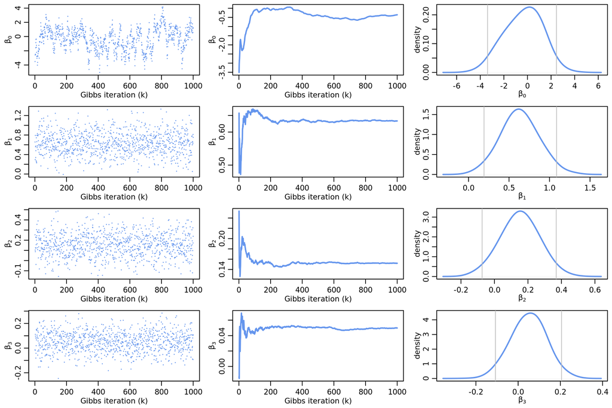

## Ordinal-Trolley

```r
data(Trolley)
```

```r
d<- Trolley %>%
  group_by(response) %>%
  count() %>%
  mutate(pr_k     = n / nrow(d)) %>%
  ungroup() %>%
  mutate(cum_pr_k = cumsum(pr_k)) %>%
  filter(response < 7)
```

```r
inits <- list(`Intercept[1]` = -2,
              `Intercept[2]` = -1,
              `Intercept[3]` = 0,
              `Intercept[4]` = 1,
              `Intercept[5]` = 2,
              `Intercept[6]` = 2.5)
inits_list <- list(inits, inits)
b11.1 <-
  brm(data = Trolley, family = cumulative,
      response ~ 1,
      prior(normal(0, 10), class = Intercept),
      iter = 2000, warmup = 1000, cores = 2, chains = 2,
      inits = inits_list,  # here we add our start values
      seed = 11)
```

> Error: Argument ‘family’ is invalid.

## Multinomial-VA

https://stackoverflow.com/questions/42114194/can-multinomial-models-be-estimated-using-generalized-linear-model

```r
data("VA",package = "MASS")
summary(VA)
```

```
##      stime              status          treat       age                Karn            diag.time         cell   prior
##  Min.   :  1.0000   Min.   :0.0000000   1:69   Min.   :34.00000   Min.   :10.00000   Min.   : 1.000000   1:35   0 :97
##  1st Qu.: 25.0000   1st Qu.:1.0000000   2:68   1st Qu.:51.00000   1st Qu.:40.00000   1st Qu.: 3.000000   2:48   10:40
##  Median : 80.0000   Median :1.0000000          Median :62.00000   Median :60.00000   Median : 5.000000   3:27
##  Mean   :121.6277   Mean   :0.9343066          Mean   :58.30657   Mean   :58.56934   Mean   : 8.773723   4:27
##  3rd Qu.:144.0000   3rd Qu.:1.0000000          3rd Qu.:66.00000   3rd Qu.:75.00000   3rd Qu.:11.000000
##  Max.   :999.0000   Max.   :1.0000000          Max.   :81.00000   Max.   :99.00000   Max.   :87.000000
```

### `nnet`

```r
nnet::multinom(cell ~ factor(treat), data=VA)%>%summary() # stime+age +Karn+diag.time
## # weights:  12 (6 variable)
## initial  value 189.922327
## iter  10 value 182.240520
## final  value 182.240516
## converged
## Call:
## nnet::multinom(formula = cell ~ factor(treat), data = VA)
##
## Coefficients:
##          (Intercept) factor(treat)2
## 2  0.693141322001006  -0.7985009423
## 3 -0.510823337092104   0.4054654242
## 4 -0.000009538147123  -0.5108138234
##
## Std. Errors:
##    (Intercept) factor(treat)2
## 2 0.3162273914   0.4533821884
## 3 0.4216358088   0.5322896825
## 4 0.3651484532   0.5163978257
##
## Residual Deviance: 364.4810311
## AIC: 376.4810311
```

### `glm`

```r
VA.tab <- table(VA[, c('cell', 'treat')])
summary(glm(Freq ~ cell * treat, data=VA.tab, family=poisson))
```

```
##
## Call:
## glm(formula = Freq ~ cell * treat, family = poisson, data = VA.tab)
##
## Deviance Residuals:
## [1]  0  0  0  0  0  0  0  0
##
## Coefficients:
##                   Estimate    Std. Error  z value Pr(>|z|)
## (Intercept)   2.708050e+00  2.581989e-01 10.48823  < 2e-16 ***
## cell2         6.931472e-01  3.162278e-01  2.19192 0.028385 *
## cell3        -5.108256e-01  4.216370e-01 -1.21153 0.225693
## cell4        -7.109355e-17  3.651484e-01  0.00000 1.000000
## treat2        2.876821e-01  3.415650e-01  0.84225 0.399650
## cell2:treat2 -7.985077e-01  4.533824e-01 -1.76122 0.078201 .
## cell3:treat2  4.054651e-01  5.322906e-01  0.76174 0.446217
## cell4:treat2 -5.108256e-01  5.163978e-01 -0.98921 0.322561
## ---
## Signif. codes:  0 '***' 0.001 '**' 0.01 '*' 0.05 '.' 0.1 ' ' 1
##
## (Dispersion parameter for poisson family taken to be 1)
##
##     Null deviance: 1.5370923e+01  on 7  degrees of freedom
## Residual deviance: 3.5527137e-15  on 0  degrees of freedom
## AIC: 53.065941
##
## Number of Fisher Scoring iterations: 3
```

## Multinomial-hsb2

```r
hsb2 <- read.table('https://stats.idre.ucla.edu/stat/data/hsb2.csv', header=TRUE, sep=",")
# Checking the output (dependent) variable
# table(hsb2$ses)
# By default the first category is the reference.
# To change it so ‘middle’ is the reference type
hsb2$ses2 = relevel(factor(hsb2$ses), ref = 2)
summary(hsb2)
```

```
##        id             female           race           ses            schtyp          prog            read           write             math           science          socst        ses2
##  Min.   :  1.00   Min.   :0.000   Min.   :1.00   Min.   :1.000   Min.   :1.00   Min.   :1.000   Min.   :28.00   Min.   :31.000   Min.   :33.000   Min.   :26.00   Min.   :26.000   2:95
##  1st Qu.: 50.75   1st Qu.:0.000   1st Qu.:3.00   1st Qu.:2.000   1st Qu.:1.00   1st Qu.:2.000   1st Qu.:44.00   1st Qu.:45.750   1st Qu.:45.000   1st Qu.:44.00   1st Qu.:46.000   1:47
##  Median :100.50   Median :1.000   Median :4.00   Median :2.000   Median :1.00   Median :2.000   Median :50.00   Median :54.000   Median :52.000   Median :53.00   Median :52.000   3:58
##  Mean   :100.50   Mean   :0.545   Mean   :3.43   Mean   :2.055   Mean   :1.16   Mean   :2.025   Mean   :52.23   Mean   :52.775   Mean   :52.645   Mean   :51.85   Mean   :52.405
##  3rd Qu.:150.25   3rd Qu.:1.000   3rd Qu.:4.00   3rd Qu.:3.000   3rd Qu.:1.00   3rd Qu.:2.250   3rd Qu.:60.00   3rd Qu.:60.000   3rd Qu.:59.000   3rd Qu.:58.00   3rd Qu.:61.000
##  Max.   :200.00   Max.   :1.000   Max.   :4.00   Max.   :3.000   Max.   :2.00   Max.   :3.000   Max.   :76.00   Max.   :67.000   Max.   :75.000   Max.   :74.00   Max.   :71.000
```

### `brms`

```r
brm.mlt.hsb2 <- brm(ses2 ~ science + socst + female, data=hsb2, family=categorical("logit"),silent = T, refresh=0)
```

```r
summary(brm.mlt.hsb2)
```

```
##  Family: categorical
##   Links: mu1 = logit; mu3 = logit
## Formula: ses2 ~ science + socst + female
##    Data: hsb2 (Number of observations: 200)
## Samples: 4 chains, each with iter = 2000; warmup = 1000; thin = 1;
##          total post-warmup samples = 4000
##
## Population-Level Effects:
##               Estimate Est.Error l-95% CI u-95% CI Rhat Bulk_ESS Tail_ESS
## mu1_Intercept     1.98      1.17    -0.29     4.26 1.00     6674     3021
## mu3_Intercept    -4.18      1.25    -6.67    -1.81 1.00     6358     3391
## mu1_science      -0.02      0.02    -0.07     0.02 1.00     4355     3063
## mu1_socst        -0.04      0.02    -0.08    -0.00 1.00     4465     3109
## mu1_female        0.84      0.40     0.05     1.65 1.00     5056     2814
## mu3_science       0.02      0.02    -0.02     0.07 1.00     4759     3331
## mu3_socst         0.04      0.02     0.01     0.08 1.00     4429     3300
## mu3_female       -0.04      0.35    -0.71     0.67 1.00     5307     2557
##
## Samples were drawn using sampling(NUTS). For each parameter, Bulk_ESS
## and Tail_ESS are effective sample size measures, and Rhat is the potential
## scale reduction factor on split chains (at convergence, Rhat = 1).
```

```r
brm.l <- fixef(brm.mlt.hsb2)[,1]
brm.l.sd <- fixef(brm.mlt.hsb2)[,2]
```

### `nnet`

```r
multi.hsb2  <-  nnet::multinom(ses2 ~ science + socst + female, hsb2)#
## # weights:  15 (8 variable)
## initial  value 219.722458
## iter  10 value 194.038495
## final  value 194.034851
## converged
summary(multi.hsb2)
```

```
## Call:
## nnet::multinom(formula = ses2 ~ science + socst + female, data = hsb2)
##
## Coefficients:
##    (Intercept)        science          socst         female
## 1  1.912288279 -0.02356494272 -0.03892428361  0.81659717417
## 3 -4.057283904  0.02292178974  0.04300322924 -0.03287210956
##
## Std. Errors:
##   (Intercept)       science         socst       female
## 1 1.127255328 0.02097467748 0.01951648505 0.3909803835
## 3 1.222937455 0.02087182108 0.01988932917 0.3500150568
##
## Residual Deviance: 388.0697023
## AIC: 404.0697023
```

### `mlogit`

```r
hsb2.mlogit <- dfidx(hsb2, shape='wide', choice = "ses2")#, varying = c(10,11, 2)
hsb2.mprobit <- mlogit(ses2 ~ 1|science + socst + female, data=hsb2.mlogit, probit = TRUE, reflevel = 2)#
summary(hsb2.mprobit)
```

```
##
## Call:
## mlogit(formula = ses2 ~ 1 | science + socst + female, data = hsb2.mlogit,
##     reflevel = 2, probit = TRUE)
##
## Frequencies of alternatives:choice
##     2     1     3
## 0.475 0.235 0.290
##
## bfgs method
## 29 iterations, 0h:0m:11s
## g'(-H)^-1g = 0.000332
## successive function values within tolerance limits
##
## Coefficients :
##                      Estimate      Std. Error  z-value Pr(>|z|)
## (Intercept):1     1.115257637     1.232440806  0.90492 0.365509
## (Intercept):3  -505.390618156 29112.207273916 -0.01736 0.986149
## science:1        -0.010505743     0.017873087 -0.58780 0.556669
## science:3         2.828312254   162.676518144  0.01739 0.986129
## socst:1          -0.025369343     0.024355937 -1.04161 0.297593
## socst:3           5.179931270   298.541826974  0.01735 0.986157
## female:1          0.507091497     0.266770819  1.90085 0.057322 .
## female:3        -23.956902291  1378.967039256 -0.01737 0.986139
## 1.3              25.094666014  1460.426398419  0.01718 0.986291
## 3.3             167.479775170  9630.010038614  0.01739 0.986124
## ---
## Signif. codes:  0 '***' 0.001 '**' 0.01 '*' 0.05 '.' 0.1 ' ' 1
##
## Log-Likelihood: -193.9711
## McFadden R^2:  0.078883258
## Likelihood ratio test : chisq = 33.222873 (p.value = 0.000056145603)
```

### Gibbs

```r
 X<-sapply(hsb2[,c(10,11)], as.numeric)# ,2
# X <- scale(X)
 X<-cbind(1,X)# ,as.numeric(hsb2[,2])
y<-hsb2$ses2
y<-match(hsb2$ses2,levels(hsb2$ses2))
# ranks<-match(y,sort(unique(y)))
uranks<-sort(unique(y))
n<-dim(X)[1] ; p<-dim(X)[2]
iXX<-solve(t(X)%*%X)  ; V<-iXX*(n/(n+1)) ; cholV<-chol(V)
```

```r
(g5 <- apply(BETA, 2, mean))
```

```
## [1] -1.552225412304  0.007588788239  0.015217491293
```

```r
(g5.marg <-mean(dnorm(X %*% g5))*g5)
```

```
## [1] -0.569589100614  0.002784705774  0.005584058288
```

Note: this method cannot include “female”

### `glmer`

```r
glmer(ses2 ~ science + socst + (1|female), hsb2, family=binomial(link = "probit"))
## Generalized linear mixed model fit by maximum likelihood (Laplace Approximation) ['glmerMod']
##  Family: binomial  ( probit )
## Formula: ses2 ~ science + socst + (1 | female)
##    Data: hsb2
##       AIC       BIC    logLik  deviance  df.resid
##  284.5375  297.7308 -138.2687  276.5375       196
## Random effects:
##  Groups Name        Std.Dev.
##  female (Intercept) 0
## Number of obs: 200, groups:  female, 2
## Fixed Effects:
##   (Intercept)        science          socst
## -0.1344177521  -0.0002347373   0.0039955628
## convergence code 0; 0 optimizer warnings; 1 lme4 warnings
```

```r
glmer(ses2 ~ science + socst + (1|female), hsb2, family=binomial(link = "logit"))
## Generalized linear mixed model fit by maximum likelihood (Laplace Approximation) ['glmerMod']
##  Family: binomial  ( logit )
## Formula: ses2 ~ science + socst + (1 | female)
##    Data: hsb2
##       AIC       BIC    logLik  deviance  df.resid
##  284.5381  297.7313 -138.2690  276.5381       196
## Random effects:
##  Groups Name        Std.Dev.
##  female (Intercept) 0
## Number of obs: 200, groups:  female, 2
## Fixed Effects:
##   (Intercept)        science          socst
## -0.2136839167  -0.0003827602   0.0063679814
## convergence code 0; 0 optimizer warnings; 1 lme4 warnings
```

## Multinomial-fish

```r
data("Fishing", package = "mlogit")
head(Fishing)
```

```
##      mode price.beach price.pier price.boat price.charter catch.beach catch.pier catch.boat catch.charter    income
## 1 charter     157.930    157.930    157.930       182.930      0.0678     0.0503     0.2601        0.5391 7083.3317
## 2 charter      15.114     15.114     10.534        34.534      0.1049     0.0451     0.1574        0.4671 1249.9998
## 3    boat     161.874    161.874     24.334        59.334      0.5333     0.4522     0.2413        1.0266 3749.9999
## 4    pier      15.134     15.134     55.930        84.930      0.0678     0.0789     0.1643        0.5391 2083.3332
## 5    boat     106.930    106.930     41.514        71.014      0.0678     0.0503     0.1082        0.3240 4583.3320
## 6 charter     192.474    192.474     28.934        63.934      0.5333     0.4522     0.1665        0.3975 4583.3320
```

```r
# From Kenneth Train’s exercises using the mlogit package for R
Fish <- dfidx(Fishing, varying = 2:9, choice = "mode", idnames = c("chid", "alt"))
summary(Fish)
```

```
##     mode             income               price               catch               idx.chid          idx.alt
##  Mode :logical   Min.   :  416.6667   Min.   :  1.29000   Min.   :0.0002000   Min.   :   1.0    beach  :1182
##  FALSE:3546      1st Qu.: 2083.3332   1st Qu.: 29.12200   1st Qu.:0.0503000   1st Qu.: 296.0    boat   :1182
##  TRUE :1182      Median : 3749.9999   Median : 59.33400   Median :0.1498000   Median : 591.5    charter:1182
##                  Mean   : 4099.3371   Mean   : 86.61996   Mean   :0.3009544   Mean   : 591.5    pier   :1182
##                  3rd Qu.: 5416.6667   3rd Qu.:114.14900   3rd Qu.:0.4522000   3rd Qu.: 887.0    NA
##                  Max.   :12499.9980   Max.   :843.18600   Max.   :2.3101000   Max.   :1182.0    NA
```

### `mlogit`

```r
Fish.mprobit <- mlogit(mode~price | income | catch, Fish, probit = TRUE, alt.subset=c('beach', 'boat','pier'))
summary(Fish.mprobit)
```

```
##
## Call:
## mlogit(formula = mode ~ price | income | catch, data = Fish,
##     alt.subset = c("beach", "boat", "pier"), probit = TRUE)
##
## Frequencies of alternatives:choice
##      beach       boat       pier
## 0.18356164 0.57260274 0.24383562
##
## bfgs method
## 14 iterations, 0h:0m:24s
## g'(-H)^-1g = 9.77E-07
## gradient close to zero
##
## Coefficients :
##                          Estimate       Std. Error  z-value           Pr(>|z|)
## (Intercept):boat  0.7251366193905  0.3580900415108  2.02501         0.04286614 *
## (Intercept):pier  0.6239290468259  0.2739641499745  2.27741         0.02276168 *
## price            -0.0121542645633  0.0017696592478 -6.86814 0.0000000000065046 ***
## income:boat       0.0000024005209  0.0000366976656  0.06541         0.94784482
## income:pier      -0.0000654190679  0.0000408317489 -1.60216         0.10911984
## catch:beach       1.5478744968064  0.4300203643170  3.59954         0.00031878 ***
## catch:boat        0.4000998541680  0.4159988399074  0.96178         0.33615953
## catch:pier        1.2747276754005  0.5586320291756  2.28187         0.02249680 *
## boat.pier         0.5456952057923  0.4626315833213  1.17955         0.23818085
## pier.pier         0.6954404768928  0.2929424413555  2.37398         0.01759734 *
## ---
## Signif. codes:  0 '***' 0.001 '**' 0.01 '*' 0.05 '.' 0.1 ' ' 1
##
## Log-Likelihood: -478.42718
## McFadden R^2:  0.32750698
## Likelihood ratio test : chisq = 465.99217 (p.value = < 2.22045e-16)
```

```r
fish <- Fish%>% subset(mode=="TRUE",select=c(income,price,catch,idx))
income <- fish$income
price <- fish$price
catch <- fish$catch
alt<- fish$idx$alt
fishing <- data.frame(alt,income,price,catch)
```

### `nnet`

```r
multi.fish  <-  nnet::multinom(mode~price + income + catch , data=Fish)
## # weights:  5 (4 variable)
## initial  value 3277.199870
## iter  10 value 2421.744473
## iter  10 value 2421.744473
## final  value 2421.744473
## converged
summary(multi.fish)
```

```
## Call:
## nnet::multinom(formula = mode ~ price + income + catch, data = Fish)
##
## Coefficients:
##                       Values        Std. Err.
## (Intercept) -0.9756029168961 0.04228620699863
## price       -0.0120560809240 0.00071768180018
## income       0.0001260205064 0.00001375140373
## catch        0.6673841337681 0.04412561102361
##
## Residual Deviance: 4843.488946
## AIC: 4851.488946
```

```r
nnet::multinom(alt~price + income + catch , data=fishing)%>%summary()
## # weights:  20 (12 variable)
## initial  value 1638.599935
## iter  10 value 1328.341919
## iter  20 value 1265.993884
## iter  20 value 1265.993881
## iter  20 value 1265.993881
## final  value 1265.993881
## converged
## Call:
## nnet::multinom(formula = alt ~ price + income + catch, data = fishing)
##
## Coefficients:
##          (Intercept)           price           income         catch
## boat    0.9880771641  0.003555725187  0.0000693061691 -1.2997214781
## charter 0.1588429847  0.022700714430 -0.0001788989977  1.4116330491
## pier    1.0836892031 -0.003027236825 -0.0001286184739 -0.9494360801
##
## Std. Errors:
##              (Intercept)          price           income             catch
## boat    0.00001767920673 0.003155493772 0.00003161360363 0.000002992347301
## charter 0.00001364347237 0.003160311024 0.00003691490862 0.000009419144224
## pier    0.00002304064575 0.003965764792 0.00004049548438 0.000005115582603
##
## Residual Deviance: 2531.987761
## AIC: 2555.987761
```

### `brms`

Note: Doesn’t work

```r
brm.mlt.fish <- brm(alt~price + income + catch , data=fishing, family=categorical("logit"),silent = T, refresh=0)
```

```r
summary(brm.mlt.fish)
brm.l.fish <- fixef(brm.mlt.fish)[,1]
brm.l.fish.sd <- fixef(brm.mlt.fish)[,2]
```

### Gibbs

```r
X<-cbind(income,price,catch)
head(X)
```

```
##         income   price  catch
## [1,] 7083.3317 182.930 0.5391
## [2,] 1249.9998  34.534 0.4671
## [3,] 3749.9999  24.334 0.2413
## [4,] 2083.3332  15.134 0.0789
## [5,] 4583.3320  41.514 0.1082
## [6,] 4583.3320  63.934 0.3975
```

```r
X<-cbind(1,scale(X))
name.rank<- names(sort(table(fish$idx$alt)))
y<-match(fish$idx$alt,name.rank)
# ranks<-match(y,sort(unique(y)))
uranks<-sort(unique(y))
n<-dim(X)[1] ; p<-dim(X)[2]
iXX<-solve(t(X)%*%X)  ; V<-iXX*(n/(n+1)) ; cholV<-chol(V)
```

Note: This method require standardize X

```r
apply(BETA, 2, mean)
```

```
## [1]  0.10241207143 -0.08741486184  0.41256899522  0.56192682052
```

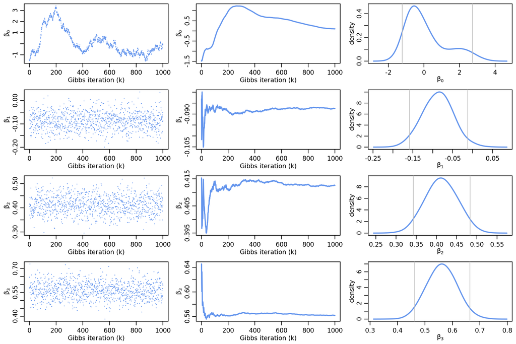

### `glmer`

```r
glmer(mode~price + income + (1|catch) , data=Fishing, family=binomial(link = "probit"))
## Generalized linear mixed model fit by maximum likelihood (Laplace Approximation) ['glmerMod']
##  Family: binomial  ( probit )
## Formula: mode ~ price + income + (1 | catch)
##    Data: Fishing
##       AIC       BIC    logLik  deviance  df.resid
##   22.7392   43.0390   -7.3696   14.7392      1178
## Random effects:
##  Groups Name        Std.Dev.
##  catch  (Intercept) 26.69023
## Number of obs: 1182, groups:  catch, 71
## Fixed Effects:
##    (Intercept)           price          income
##  5.68905038918   0.00719111472  -0.00002839459
## fit warnings:
## Some predictor variables are on very different scales: consider rescaling
## convergence code 0; 0 optimizer warnings; 2 lme4 warnings
```

```r
glmer(mode~price + income + (1|catch) , data=Fishing, family=binomial(link = "logit"))
## Generalized linear mixed model fit by maximum likelihood (Laplace Approximation) ['glmerMod']
##  Family: binomial  ( logit )
## Formula: mode ~ price + income + (1 | catch)
##    Data: Fishing
##       AIC       BIC    logLik  deviance  df.resid
##   21.7464   42.0463   -6.8732   13.7464      1178
## Random effects:
##  Groups Name        Std.Dev.
##  catch  (Intercept) 95.56866
## Number of obs: 1182, groups:  catch, 71
## Fixed Effects:
##    (Intercept)           price          income
## 17.88030302420   0.00454845896  -0.00005596308
## fit warnings:
## Some predictor variables are on very different scales: consider rescaling
## convergence code 0; 0 optimizer warnings; 3 lme4 warnings
```

## Multinomial-marital

### ‘bamlss’

```r
data("marital.nz", package = "VGAM")
```

```r
library(bamlss)
d <- GAMart()
f <- num ~ s(x1) + s(x2) + s(x3) + te(lon, lat)
b <- bamlss(f, data = d)
```

```r
## Model formula, each category may have different model terms.
f <- list(mstatus ~ s(age),
                  ~ s(age),
                  ~ s(age))
set.seed(123)
bamlss1 <- bamlss::bamlss(f, family = "multinomial", data = marital.nz,reference = "Married/Partnered",
                              optimizer = bfit, sampler = FALSE)
```

## Dirichlet-multinomial

```r
test_that('Dirichlet-multinomial conjugacy setup', {
### Dirichlet-multinomial conjugacy

# as of v0.4, exact numerical results here have changed because
# ddirch now sometimes returns NaN rather than -Inf (when an
# alpha is proposed to be negative) -- this changes the RNG
# sequence because NaN values result in no runif() call in decide()

# single multinomial
    set.seed(0)
    n <- 100
    alpha <- c(10, 30, 15, 60, 1)
    K <- length(alpha)
    p <- c(.12, .24, .09, .54, .01)
    y <- rmulti(1, n, p)

    code <- function() {
        y[1:K] ~ dmulti(p[1:K], n);
        p[1:K] ~ ddirch(alpha[1:K]);
        for(i in 1:K) {
            alpha[i] ~ dgamma(.001, .001);
        }
    }

    inits <- list(p = rep(1/K, K), alpha = rep(K, K))
    data <- list(n = n, K = K, y = y)

    test_mcmc(model = code, name = 'Dirichlet-multinomial example', data= data, seed = 0, numItsC = 10000,
              inits = inits,
              results = list(mean = list(p = p)),
              resultsTolerance = list(mean = list(p = rep(.06, K))), avoidNestedTest = TRUE)
})
## bad mixing for alphas; probably explains why posterior estimates for alphas changed so much as of v 0.4

## with replication
test_that('Dirichlet-multinomial with replication setup', {
    set.seed(0)
    n <- 100
    m <- 20
    alpha <- c(10, 30, 15, 60, 1)
    K <- length(alpha)
    y <- p <- matrix(0, m, K)
    for(i in 1:m) {
        p[i, ] <- rdirch(1, alpha)
        y[i, ] <- rmulti(1, n, p[i, ])
    }

    code <- function() {
        for(i in 1:m) {
            y[i, 1:K] ~ dmulti(p[i, 1:K], n);
            p[i, 1:K] ~ ddirch(alpha[1:K]);
        }
        for(i in 1:K) {
            alpha[i] ~ dgamma(.001, .001);
        }
    }

    inits <- list(p = matrix(1/K, m, K), alpha = rep(1/K, K))
    data <- list(n = n, K = K, m = m, y = y)

    ## two tolerance failures are known, for p[39] and p[76]
    test_mcmc(model = code, name = 'Dirichlet-multinomial with replication', data= data,
              seed = 0, numItsC = 1000,
              inits = inits, numItsC_results = 100000,
              results = list(mean = list(p = p, alpha = alpha)),
              resultsTolerance = list(mean = list(p = matrix(.05, m, K),
                                                  alpha = c(5,10,10,20,.5))),
              knownFailures = list('MCMC match to known posterior: p mean 39' = 'KNOWN ISSUE: two samples outside resultsTolerance',
                                  'MCMC match to known posterior: p mean 76' = 'KNOWN ISSUE: two samples outside resultsTolerance'), avoidNestedTest = TRUE)
})
# note alphas mix poorly (and are highly correlated),
# presumably because of cross-level dependence between
# p's and alphas.  cross-level sampler would probably work well here,
# or, of course, integrating over the p's

test_that('Dirichlet-categorical conjugacy setup', {
### Dirichlet-categorical conjugacy

# single multinomial represented as categorical
    set.seed(0)
    n <- 100
    alpha <- c(10, 30, 15, 60, 1)
    K <- length(alpha)
    p <- c(.12, .24, .09, .54, .01)
    y <- rmulti(1, n, p)
    y <- rep(seq_along(y), times = y)

    code <- function() {
        for(i in 1:n)
          y[i] ~ dcat(p[1:K])
        p[1:K] ~ ddirch(alpha[1:K])
        for(i in 1:K) {
            alpha[i] ~ dgamma(.001, .001);
        }
    }

    inits <- list(p = rep(1/K, K), alpha = rep(K, K))
    data <- list(n = n, K = K, y = y)

    test_mcmc(model = code, name = 'Dirichlet-categorical example', data= data, seed = 0, numItsC = 10000,
              inits = inits,
              results = list(mean = list(p = p)),
              resultsTolerance = list(mean = list(p = rep(.06, K))), avoidNestedTest = TRUE)
})

## also note that MCMC results here should be identical to those from
## Dirichlet-multinomial case two tests up from this
```

## Summary

| $y\in$ | link fn | cont’us X |  |  |  |  |  | discrete X |
| --- | --- | --- | --- | --- | --- | --- | --- | --- |
|  |  | fixed $\beta$ |  |  |  |  | random $\beta$ |  |
|  |  | Manual | `nimble` | `brms` | `glm` | `mlogit` | `glmer` |  |
| $\{0,1\}$ | $\Phi$ | $\checkmark$ | $\checkmark$ | $\checkmark$ | $\checkmark$ |  | $\checkmark$ |  |
|  | Logit |  | $\checkmark$ | $\checkmark$ | $\checkmark$ | $\checkmark$ | $\checkmark$ |  |
|  |  |  |  |  | `polr` |  |  |  |
| $\{1,2,..\}$ | $\Phi$ | $\checkmark$ |  |  | $\checkmark$ |  | $\checkmark$ |  |
|  | Logit |  |  | $\checkmark$ | $\checkmark$ |  | $\checkmark$ |  |
|  |  |  |  |  | `nnet` |  |  |  |
| {A,B,..} | $\Phi$ |  |  |  |  | $\checkmark$ | $\checkmark$ |  |
|  | Logit |  |  | $\checkmark$ |  | $\checkmark$ | $\checkmark$ |  |
|  | log |  |  |  | $\checkmark$ |  |  |  |
| {(A,B),C,.} | $\Phi$ |  |  |  |  | $\checkmark$ |  |  |
|  | Logit |  |  |  |  | $\checkmark$ |  |  |

Nested

Mixed

Hierarchical

## Resources

[Charlie Geyer’s Personal Home Page](http://users.stat.umn.edu/~geyer/)

[McElreath 2020. Statistical Rethinking](https://xcelab.net/rm/statistical-rethinking/)

[R package rethinking](https://github.com/rmcelreath/rethinking)

https://cran.r-project.org/web/packages/bayesm/vignettes/bayesm_Overview_Vignette.html

https://bayesr.r-forge.r-project.org/index.html